# Prey Data Aggregation and Exploration

Maddee Rubenson & Erin Cain (FlowWest)

2022-05-31

## Standardized Dataset Format

Formatting and data descriptions for standardized datasets.

|  | Variable | Type | Description | Corline | Cordoleani | Zeug - Merced | Zeug - San Joaquin | Montgomery | Guignard | Zooper |
| --- | --- | --- | --- | --- | --- | --- | --- | --- | --- | --- |
| 1 | date | date; YYYY-MM-DD | sampling date | True | True | True | False | True | True | True |
| 2 | prey_density | numeric; total organisms/liter | total fish prey per unit volume | True | True | True | True | True | True | True |
| 3 | life_stage | categorical | Adult, Larvae, Nymph, Pupae | True | False | True | False | True | False | True |
| 4 | species | categorical | Zooplankton species | True | True | True | True | True | True | True |
| 5 | habitat_type | categorical | perennial instream, floodplain, side channel | True | True | True | True | True | True | False |
| 6 | gear_type | categorical | kick net, drift net, etc. | True | True | True | True | True | True | False |
| 7 | site | varchar | unique site id that can be used to join to other datasets | True | True | True | True | True | True | True |
| 8 | author | categorical | dataset author | True | True | True | True | True | True | True |
| 9 | lat/long | numeric | specific location of sampling event | True | True | False | True | True | True | False |
| 10 | watershed | categorical | unique watershed name | True | True | True | True | True | True | False |

[output cut: 2 more lines]

|  | Variable | Type | Description | Corline | Cordoleani | Zeug - Merced | Zeug - San Joaquin | Montgomery | Guignard | Zooper |
| --- | --- | --- | --- | --- | --- | --- | --- | --- | --- | --- |
| 1 | date | date; YYYY-MM-DD | sampling date | False | True | False | False | True | False | False |
| 2 | fish_id | varchar | unique id for sampled fish | False | True | True | False | True | False | False |
| 3 | site | varchar | unique site id that can be used to join to other datasets | False | True | True | False | True | False | False |
| 4 | mass | numeric; grams | weight of sampled fish | False | True | True | False | True | False | False |
| 5 | fork_length | numeric; millimeters | fork length of sampled fish | False | True | True | False | True | False | False |
| 6 | author | categorical | dataset author | False | True | True | False | True | False | False |
| 7 | lat/long | numeric | specific location of sampling event | False | True | True | False | True | False | False |
| 8 | stream | categorical | unique stream reach name | False | True | True | False | True | False | False |

|  | Variable | Type | Description | Corline | Cordoleani | Zeug - Merced | Zeug - San Joaquin | Montgomery | Guignard | Zooper |
| --- | --- | --- | --- | --- | --- | --- | --- | --- | --- | --- |
| 1 | date | date; YYYY-MM-DD | sampling date | False | True | True | False | True | True | True |
| 2 | site | varchar | unique site id that can be used to join to other datasets | False | True | True | False | True | False | True |
| 3 | temperature | numeric; degrees celsius | measured temperature | False | True | True | False | True | True | True |
| 4 | do_mg_l | numeric; mg/l | measured dissolved oxygen | False | True | False | False | True | False | False |
| 5 | author | categorical | dataset author | False | True | True | False | True | True | True |
| 6 | lat/long | numeric | specific location of sampling event | False | True | False | False | False | False | True |
| 7 | watershed | categorical | unique watershed name | False | True | True | False | False | True | False |

# Load Datasets

### Corline et al.

#### Load Raw Data

```r
corline_raw_zoop <- read_excel("corline/Zoop2013_2016.xlsx")

kable(head(corline_raw_zoop, 5))
```

| Date | Location | Field | Method | Throws | Mesh Size (microns) | Ring Size (cm) | Total Volume (ml) | Split Fraction | Volume subsampled (ml) | Phylum | Class | Subclass | Order | Family | Genus | Species | Life Stage | Count |
| --- | --- | --- | --- | --- | --- | --- | --- | --- | --- | --- | --- | --- | --- | --- | --- | --- | --- | --- |
| 2013-02-13 | Knaggs Ranch | Field 1 | Net Throw | 4 | 153 | 30 | 100 | 1 | 21 | Arthopoda | NA | NA | Cladocera | Bosmina | Bosmina | Bosmina | adult | 12 |
| 2013-02-13 | Knaggs Ranch | Field 1 | Net Throw | 4 | 153 | 30 | 100 | 1 | 21 | Arthopoda | NA | NA | Cladocera | Chydoridae | chydorus | chydorus | adult | 38 |
| 2013-02-13 | Knaggs Ranch | Field 1 | Net Throw | 4 | 153 | 30 | 100 | 1 | 21 | Arthopoda | NA | NA | Cladocera | Daphniidae | Ceriodaphnia | Ceriodaphnia | adult | 13 |
| 2013-02-13 | Knaggs Ranch | Field 1 | Net Throw | 4 | 153 | 30 | 100 | 1 | 21 | Arthopoda | NA | NA | Cladocera | Daphniidae | Daphnia | pulex | adult | 30 |
| 2013-02-13 | Knaggs Ranch | Field 1 | Net Throw | 4 | 153 | 30 | 100 | 1 | 21 | Arthopoda | NA | NA | Cladocera | Daphniidae | Daphnia | laevis | adult | 7 |

#### Data Standardization

- Corline defined prey density as `Count` per `Volume subsampled (ml)`
- converted volume subsampled from ml to liters
- Along with `gear_type` included in the datest are the number of throws (`n_throws`) and mesh size (`mesh_size_microns`). Mesh size is used to determine the `size_class` variable.
- Variables Removed: `Split Fraction`, `Class`, `Subclass`, `Order`, `Genus`, `Family`
- Left `species` column
- Fixed naming conventions of the sampling locations (`sample_id`)
- TO DO: reconcile inconsistent species spelling names

```r
corline_zoop <- corline_raw_zoop %>%
  rename(location = Location,
         gear_type = Method,
         life_stage = `Life Stage`) %>%
  mutate(prey_density = Count/(`Volume subsampled (ml)`*0.001), #convert ml to L and calculate prey density
         # mutate(prey_density = Count/(`Total Volume (ml)`*1e-6), #convert ml to L and calculate prey density
         Date = as_date(Date)) %>%
  select(-c(`Split Fraction`:`Volume subsampled (ml)`), -Count, -c(Phylum:Genus)) %>%
  rename(sample_id = Field,
         species = Species,
         n_throws = Throws,
         mesh_size_microns = `Mesh Size (microns)`,
         date = Date) %>%
  select(-`Total Volume (ml)`, -`Ring Size (cm)`) %>%
  mutate(author = "Corline",
         size_class = "meso",
         species = tolower(species),
         gear_type = tolower(gear_type),
         mesh_size = mesh_size_microns)

table(corline_zoop$species)
```

```
##
##   acanthocyclops            acari            alona        amphipoda
##              148               10               46                3
##          bosmina        calinoida  ceratopogonidae     ceriodaphnia
##              153              103                1              148
##     chironomidae       chydoridae         chydorus   coenagrionidae
##               64               26              154                3
##       collembola        corixidae       cyclopidae       cyclopoida
##               14                3              284                1
##      cypridopsis          daphnia        daphnidae       daphniidae
##               64                1               21               85
##       diacyclops diplotesticulata        eubosmina         eucypris
##                4               21                3              211
##       eurycercus       gastropoda     harpacticoid    harpacticoida
##               14                5               10                1
##       holopedium            hydra   illyocryptidae    ilyocryptidae
##                1                7                3                1
##       ilyocypris           laevis       longiremus     longirostrus
##               35               75                1                3
##    macrothixidae            magna      megaloptera            miona
##                1               31                1                3
##           mixtus         nematoda          parvula       plecoptera
##              146               18               32                2
##       podacopida     potamocypris            pulex         rotifera
##                1                2              155              119
##    schaphloberis     schaploberis             sida          species
##               11                3               16                1
##      tardigrades
##                1
```

```r
#Numeric sample Ids must be standardized with Fields. Looks like 2015 data has 1 - 9 as sample Id while data from 2013 has Field 1 - Field 9. This is updated to have the sample_ids as follows, where the NA corresponds to the sites on the Sacramento River.
tmp_change_names <- corline_zoop[corline_zoop$sample_id %in% c(1:10), ] %>%
  mutate(sample_id = paste0('Field ', sample_id))
tmp_names_with_field <- corline_zoop[!(corline_zoop$sample_id %in% c(1:10)), ]
corline_zoop <- bind_rows(tmp_change_names, tmp_names_with_field)

# this fixes he spelling differences in species column
corline_zoop <- corline_zoop %>%
  mutate(species = case_when(species %in% c("harpacticoid", "harpacticoida") ~ "harpacticoida",
                             species %in% c("illyocryptidae", "ilyocryptidae") ~ "ilyocryptidae",
                             species %in% c("schaploberis", "schaphloberis") ~ "schaphloberis",
                             species == "species" ~ NA_character_,
                             TRUE ~ species))  %>% glimpse
```

```
## Rows: 2,270
## Columns: 12
## $ date              <date> 2014-01-31, 2014-01-31, 2014-01-31, 2014-01-31, 201…
## $ location          <chr> "Knaggs Ranch", "Knaggs Ranch", "Knaggs Ranch", "Kna…
## $ sample_id         <chr> "Field 2", "Field 2", "Field 2", "Field 2", "Field 2…
## $ gear_type         <chr> "net throw", "net throw", "net throw", "net throw", …
## $ n_throws          <dbl> 4, 4, 4, 4, 4, 4, 4, 4, 4, 4, 4, 4, 4, 4, 4, 4, 4, 4…
## $ mesh_size_microns <dbl> 153, 153, 153, 153, 153, 153, 153, 153, 153, 153, 15…
## $ species           <chr> "bosmina", "chydoridae", "chydorus", "ceriodaphnia",…
## $ life_stage        <chr> "adult", "adult", "adult", "adult", "adult", "adult"…
## $ prey_density      <dbl> 5600, 2400, 109600, 40800, 108000, 1600, 17600, 7520…
## $ author            <chr> "Corline", "Corline", "Corline", "Corline", "Corline…
## $ size_class        <chr> "meso", "meso", "meso", "meso", "meso", "meso", "mes…
## $ mesh_size         <dbl> 153, 153, 153, 153, 153, 153, 153, 153, 153, 153, 15…
```

```r
corline_zoop <- corline_zoop %>%
  select(-n_throws, -mesh_size_microns)

#kable(head(corline_zoop, 5))
```

##### Location Data Standardization and Merge

- location of the fields (Knaggs Ranch) were provided by author
- location of inlet canal (Toe Drain) was determined based on best professional judgement and the paper Corline et al.
- location of the Sacramento River sampling site was provided in the paper Corline et al. as Sherwood Harbor
- defined `habitat_type` based on best professional judgement

```r
corline_locations <- data.frame(
  location = c('Knaggs Ranch', 'Sacramento River', 'Toe Drain'),
  habitat_type = c('floodplain', 'perennial instream', 'agricultural canal'),
  lat = c(38.70151, 38.52353, 38.70511),
  lon = c( -121.66996, -121.53840, -121.67041)
)

corline_locations_sf <- st_as_sf(corline_locations, coords = c('lon', 'lat'))

# leaflet(corline_locations_sf) %>%
#   addEsriBasemapLayer(esriBasemapLayers$Imagery,
#                       autoLabels=TRUE, group = 'Esri Basemap') %>%
#   addMarkers(popup = ~paste0(corline_locations_sf$location, ' ', corline_locations_sf$habitat_type ))
```

##### Combine locations and zooplankton dataset

```r
corline_zoop <- merge(corline_zoop, corline_locations, by = "location")

# add watershed column
corline_zoop <- corline_zoop %>%
  mutate(watershed = ifelse(location == "Sacramento River", "Sacramento River", "Yolo Bypass"),
         site = ifelse(location == "Sacramento River", "Sherwood Harbor", location)) %>%
  mutate(site = paste0(location, "-", sample_id)) %>%
  select(-sample_id, -location)


kable(head(corline_zoop, 5))
```

| date | gear_type | species | life_stage | prey_density | author | size_class | mesh_size | habitat_type | lat | lon | watershed | site |
| --- | --- | --- | --- | --- | --- | --- | --- | --- | --- | --- | --- | --- |
| 2014-01-31 | net throw | bosmina | adult | 5600 | Corline | meso | 153 | floodplain | 38.70151 | -121.67 | Yolo Bypass | Knaggs Ranch-Field 2 |
| 2014-01-31 | net throw | chydoridae | adult | 2400 | Corline | meso | 153 | floodplain | 38.70151 | -121.67 | Yolo Bypass | Knaggs Ranch-Field 2 |
| 2014-01-31 | net throw | chydorus | adult | 109600 | Corline | meso | 153 | floodplain | 38.70151 | -121.67 | Yolo Bypass | Knaggs Ranch-Field 2 |
| 2014-01-31 | net throw | ceriodaphnia | adult | 40800 | Corline | meso | 153 | floodplain | 38.70151 | -121.67 | Yolo Bypass | Knaggs Ranch-Field 2 |
| 2014-01-31 | net throw | pulex | adult | 108000 | Corline | meso | 153 | floodplain | 38.70151 | -121.67 | Yolo Bypass | Knaggs Ranch-Field 2 |

#### Data Exploration

##### Location Background Information

- There are 9 sampling sites located on agricultural fields[^1]
- There is one sampling location on the Sacramento River [^2]
- There is one sampling location on an Inlet Canal[^3]

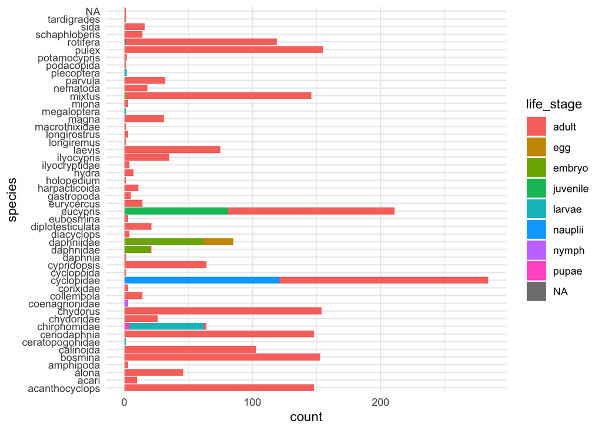

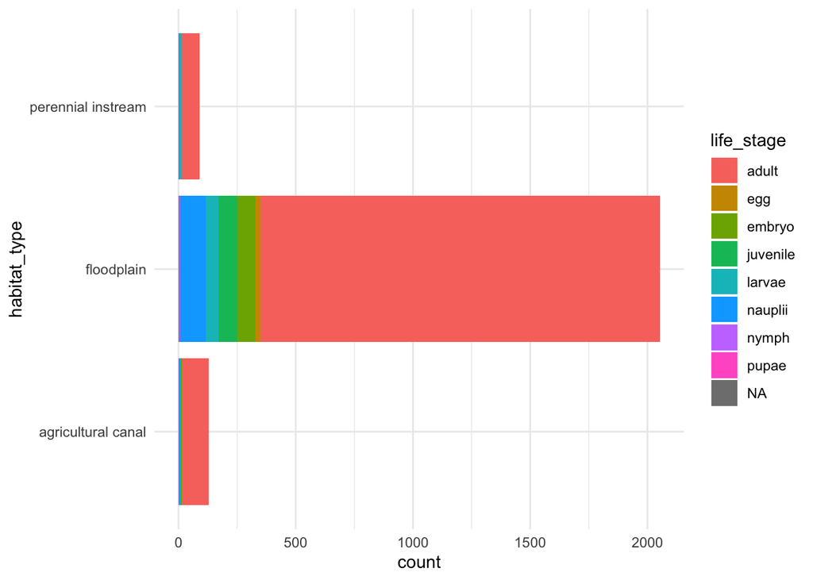

```r
ggplot(corline_zoop, aes(habitat_type)) +
  geom_bar(aes(stat = 'count', fill = life_stage)) +
  coord_flip() +
  theme_minimal()
```

### Cordoleani et al.

#### Load Raw Data

##### Raw Fish Data

```r
fish_growth_data_2019 <- read_csv("Cordoleani et al Sutter Bypass CVPIA 2020 2021/DailyCageFish_data_2019.csv")
fish_growth_data_2020 <- read_csv("Cordoleani et al Sutter Bypass CVPIA 2020 2021/DailyCageFish_data_2020.csv")

# combine 2019, 2020 data
total_fish_growth <- bind_rows(fish_growth_data_2019, fish_growth_data_2020)

# view snapshot or results
kable(head(total_fish_growth, 5))
```

| fish_id | cage_id | Region | Type | Date | mass | mass_interp | mass_fill |
| --- | --- | --- | --- | --- | --- | --- | --- |
| 3953 | SBFR | Upper Bypass | Agriculture | 2019-02-19 | NA | 1.154335 | 1.154335 |
| 3953 | SBFR | Upper Bypass | Agriculture | 2019-02-20 | NA | 1.154335 | 1.154335 |
| 3953 | SBFR | Upper Bypass | Agriculture | 2019-02-21 | 1.154335 | 1.154335 | 1.154335 |
| 3953 | SBFR | Upper Bypass | Agriculture | 2019-02-22 | NA | 1.188194 | 1.154335 |
| 3953 | SBFR | Upper Bypass | Agriculture | 2019-02-23 | NA | 1.222054 | 1.154335 |

```r
# read in fork length data
fork_length <- read.csv('Cordoleani et al Sutter Bypass CVPIA 2020 2021/CageSalmon_Growth.csv')
```

##### Raw Prey Data

```r
prey_data_2019 <- read_csv("Cordoleani et al Sutter Bypass CVPIA 2020 2021/DailyZoopTemp_data_2019.csv")
prey_data_2020 <- read_csv("Cordoleani et al Sutter Bypass CVPIA 2020 2021/DailyZoopTemp_data_2020.csv") %>%
  mutate(Date = lubridate::as_date(Date, format = "%d/%m/%y"))

# combine 2019, 2020 data
total_prey <- bind_rows(prey_data_2019, prey_data_2020)

# view snapshot or results
kable(head(total_prey, 5))
```

| cage_id | Region | Type | Date | totprey_density | totcladocera_density | totpulex_density | totprey_density_interp | totcladocera_density_interp | totpulex_density_interp | totprey_density_fill | totcladocera_density_fill | totpulex_density_fill | mean_temperature | min_temperature | max_temperature | Report_type |
| --- | --- | --- | --- | --- | --- | --- | --- | --- | --- | --- | --- | --- | --- | --- | --- | --- |
| BCGR | Butte Sink | Channel | 2019-02-11 | NA | NA | NA | 524.0314 | 273.2679 | 69.12071 | 524.0314 | 273.2679 | 69.12071 | NA | NA | NA | NA |
| BCGR | Butte Sink | Channel | 2019-02-12 | NA | NA | NA | 524.0314 | 273.2679 | 69.12071 | 524.0314 | 273.2679 | 69.12071 | NA | NA | NA | NA |
| BCGR | Butte Sink | Channel | 2019-02-13 | NA | NA | NA | 524.0314 | 273.2679 | 69.12071 | 524.0314 | 273.2679 | 69.12071 | NA | NA | NA | NA |
| BCGR | Butte Sink | Channel | 2019-02-14 | NA | NA | NA | 524.0314 | 273.2679 | 69.12071 | 524.0314 | 273.2679 | 69.12071 | NA | NA | NA | NA |
| BCGR | Butte Sink | Channel | 2019-02-15 | NA | NA | NA | 524.0314 | 273.2679 | 69.12071 | 524.0314 | 273.2679 | 69.12071 | NA | NA | NA | NA |

```r
cord_prey_new <- read.csv('Cordoleani et al Sutter Bypass CVPIA 2020 2021/tidy_zoop_density.csv')
```

##### Raw Location Data

```r
cordoleani_locations_raw <- read.csv('Cordoleani et al Sutter Bypass CVPIA 2020 2021/Cage_Locations.csv')

kable(head(cordoleani_locations_raw, 5 ))
```

| Region | Name | Site | Type | Report_type | Report_ID | lat | long |
| --- | --- | --- | --- | --- | --- | --- | --- |
| Butte Sink | Sanborn Slough | BSSS | Wetland | Wetland | BSW1 | 39.3481 | -121.8901 |
| Butte Sink | Mallard Ranch | BSMR | Wetland | Wetland | BSW2 | 39.2858 | -121.9246 |
| Butte Sink | Butte Creek adjacent to Sanborn Slough | BCGR | Canal | Canal channel | BSC1 | 39.3607 | -121.8936 |
| Butte Sink | Laux Rd Rice | BSLR | Wetland | Agriculture | BSA1 | 39.2350 | -121.9470 |
| Butte Sink | Butte Creek adjacent to laux rice | BCLC | Canal | Canal channel | BSC2 | 39.2398 | -121.9480 |

##### Raw Dissolved Oxygen Data

```r
cordoleani_do_raw <- read.csv('Cordoleani et al Sutter Bypass CVPIA 2020 2021/doboall.csv')

kable(head(cordoleani_do_raw, 5))
```

| Site | Region | Report_type | Report_ID | Datetime | DO_mgl | Temp_C | Date | percsat | Year | minDOmod | maxDOmod | meanDOmod | minDOmglmod | maxDOmglmod | meanDOmglmod | minTempmod | maxTempmod | meanTempmod | IDyear |
| --- | --- | --- | --- | --- | --- | --- | --- | --- | --- | --- | --- | --- | --- | --- | --- | --- | --- | --- | --- |
| BCGR | Butte Sink | Canal channel | BSC1 | 2020-03-05 11:30:00 | 8.21 | 13.68 | 2020-03-05 | 79.18203 | 2020 | 72.16881 | 87.50625 | 82.33623 | 7.394797 | 8.857725 | 8.404080 | 13.53056 | 14.99687 | 14.35872 | BSC1 2020 |
| BCGR | Butte Sink | Canal channel | BSC1 | 2020-03-05 11:15:00 | 8.21 | 13.66 | 2020-03-05 | 79.14640 | 2020 | 72.15697 | 87.53045 | 82.34708 | 7.393409 | 8.860233 | 8.405386 | 13.53027 | 14.99600 | 14.35780 | BSC1 2020 |
| BCGR | Butte Sink | Canal channel | BSC1 | 2020-03-05 14:45:00 | 8.34 | 14.46 | 2020-03-05 | 81.84995 | 2020 | 72.32924 | 87.25318 | 82.22709 | 7.414243 | 8.832585 | 8.391653 | 13.53090 | 15.00273 | 14.36436 | BSC1 2020 |
| BCGR | Butte Sink | Canal channel | BSC1 | 2020-03-05 11:00:00 | 8.13 | 13.60 | 2020-03-05 | 78.26937 | 2020 | 72.14522 | 87.55523 | 82.35823 | 7.392039 | 8.862813 | 8.406737 | 13.52993 | 14.99506 | 14.35682 | BSC1 2020 |
| BCGR | Butte Sink | Canal channel | BSC1 | 2020-03-05 14:15:00 | 8.38 | 14.34 | 2020-03-05 | 82.02358 | 2020 | 72.30393 | 87.28380 | 82.23960 | 7.411101 | 8.835457 | 8.392963 | 13.53127 | 15.00253 | 14.36429 | BSC1 2020 |

#### Data Standardization

##### Prey Data Standardization

```r
cordoleani_zoop <- cord_prey_new %>%
  rename(prey_density = value, # units are organisms/m^3 per Sutter 2020 report
         sample_id = report_id,
         date = sample_date,
         location = region,
         species = taxa) %>%
  mutate(date = mdy(date),
         prey_density = prey_density/1000, # 1 m^3 = 1000 Liters
         author = 'Cordoleani',
         habitat_type = ifelse(habitat_type == "Agriculture", 'agricultural canal',
                               ifelse(habitat_type == 'Channel', 'perennial instream',
                                      ifelse(habitat_type == "River Channel", 'perennial instream',
                                             ifelse(habitat_type == 'Wetland', 'floodplain', 'agricultural canal' )))),
         watershed = case_when(location == "Butte Sink" ~ "Butte Creek",
                            location == "Sacramento River" ~ "Sacramento River",
                            location == "Feather River" ~ "Feather River",
                            location %in% c("Lower Bypass", "Upper Bypass") ~
                              "Sutter Bypass"),
         site = paste0(location, "-", sample_id),
         size_class = "meso",
         gear_type = "net throw",
         mesh_size = 150,
         species = tolower(species)) %>%
         select(-location, -sample_id, -year)


# cordoleani_zoop <- total_prey %>%
#   select(cage_id:totprey_density,totcladocera_density, totpulex_density, mean_temperature, Report_type) %>%
#   mutate(habitat_type = ifelse(is.na(total_prey$Type), total_prey$Report_type, total_prey$Type)) %>%
#   rename(prey_density = totprey_density, # units are organisms/m^3 per Sutter 2020 report
#          location = Region,
#          sample_id = cage_id) %>%
#   filter(!is.na(prey_density)) %>%
#   mutate(prey_density = prey_density/1000, # 1 m^3 = 1000 Liters
#          author = 'Cordoleani') %>%
#   select(-Type, -Report_type, -mean_temperature) %>%
#   rename(date = Date) %>%
#   select(-totcladocera_density, -totpulex_density) %>%
#   mutate(habitat_type = ifelse(habitat_type == "Agriculture", 'agricultural canal',
#                                ifelse(habitat_type == 'Channel', 'perennial instream',
#                                       ifelse(habitat_type == "River Channel", 'perennial instream',
#                                              ifelse(habitat_type == 'Wetland', 'floodplain', 'agricultural canal' ))))) %>%
#   mutate(watershed = case_when(location == "Butte Sink" ~ "Butte Creek",
#                             location == "Sacramento River" ~ "Sacramento River",
#                             location == "Feather River" ~ "Feather River",
#                             location %in% c("Lower Bypass", "Upper Bypass") ~
#                               "Sutter Bypass"),
#          site = paste0(location, "-", sample_id),
#          size_class = "meso",
#          gear_type = "net throw",
#          mesh_size = 150) %>%
#   select(-location, -sample_id) %>%
#   glimpse


# view data snapshot
kable(head(cordoleani_zoop, 5))
```

| habitat_type | date | species | prey_density | author | watershed | site | size_class | gear_type | mesh_size |
| --- | --- | --- | --- | --- | --- | --- | --- | --- | --- |
| agricultural canal | 2019-01-07 | aquatic insect | 0.1273240 | Cordoleani | Butte Creek | Butte Sink-BSC1 | meso | net throw | 150 |
| agricultural canal | 2019-01-07 | copepoda | 0.6507669 | Cordoleani | Butte Creek | Butte Sink-BSC1 | meso | net throw | 150 |
| agricultural canal | 2019-01-07 | large cladocera | 0.7568702 | Cordoleani | Butte Creek | Butte Sink-BSC1 | meso | net throw | 150 |
| agricultural canal | 2019-01-07 | ostracoda | 0.0070736 | Cordoleani | Butte Creek | Butte Sink-BSC1 | meso | net throw | 150 |
| agricultural canal | 2019-01-07 | rare | 0.1839124 | Cordoleani | Butte Creek | Butte Sink-BSC1 | meso | net throw | 150 |

##### Environmental Data Standardization

```r
cordoleani_enviro <- cordoleani_do_raw %>%
  select(Region, Report_type,
         Date, DO_mgl, Temp_C, Report_ID) %>%
  rename(sample_id = Report_ID,
         location = Region,
         do_mg_l = DO_mgl,
         temperature = Temp_C,
         date = Date,
         habitat_type = Report_type) %>%
  mutate(date = as_date(date),
         author = 'Cordoleani') %>%
  mutate(habitat_type = ifelse(habitat_type == "Agriculture", 'agricultural canal',
                               ifelse(habitat_type == 'Channel', 'perennial instream',
                                      ifelse(habitat_type == "River Channel", 'perennial instream',
                                             ifelse(habitat_type == 'Wetland', 'floodplain', 'agricultural canal' ))))) %>%
  mutate(watershed = case_when(location == "Butte Sink" ~ "Butte Creek",
                            location == "Sacramento River" ~ "Sacramento River",
                            location == "Feather River" ~ "Feather River",
                            location %in% c("Lower Bypass", "Upper Bypass") ~ "Sutter Bypass"),
         site = paste0(location, "-", sample_id)) %>%
  select(-location, -sample_id) %>%
  glimpse
```

```
## Rows: 155,349
## Columns: 7
## $ habitat_type <chr> "agricultural canal", "agricultural canal", "agricultural…
## $ date         <date> 2020-03-05, 2020-03-05, 2020-03-05, 2020-03-05, 2020-03-…
## $ do_mg_l      <dbl> 8.21, 8.21, 8.34, 8.13, 8.38, 8.35, 8.25, 8.37, 8.37, 8.2…
## $ temperature  <dbl> 13.68, 13.66, 14.46, 13.60, 14.34, 14.40, 13.76, 14.50, 1…
## $ author       <chr> "Cordoleani", "Cordoleani", "Cordoleani", "Cordoleani", "…
## $ watershed    <chr> "Butte Creek", "Butte Creek", "Butte Creek", "Butte Creek…
## $ site         <chr> "Butte Sink-BSC1", "Butte Sink-BSC1", "Butte Sink-BSC1", …
```

```r
# view data snapshot
kable(head(cordoleani_enviro, 5))
```

| habitat_type | date | do_mg_l | temperature | author | watershed | site |
| --- | --- | --- | --- | --- | --- | --- |
| agricultural canal | 2020-03-05 | 8.21 | 13.68 | Cordoleani | Butte Creek | Butte Sink-BSC1 |
| agricultural canal | 2020-03-05 | 8.21 | 13.66 | Cordoleani | Butte Creek | Butte Sink-BSC1 |
| agricultural canal | 2020-03-05 | 8.34 | 14.46 | Cordoleani | Butte Creek | Butte Sink-BSC1 |
| agricultural canal | 2020-03-05 | 8.13 | 13.60 | Cordoleani | Butte Creek | Butte Sink-BSC1 |
| agricultural canal | 2020-03-05 | 8.38 | 14.34 | Cordoleani | Butte Creek | Butte Sink-BSC1 |

##### Fish Data Standardization

- Defined `sample_id` as `cage_id`
- merged fish growth dataset with fork length dataset, which we acquired separately
- used average `fork_length` per site because fish growth dataset wasn’t granular enough in terms of date and time to merge with fork length dataset.
- used same mapping as shown in prey data standardization

```r
cordoleani_fish <- total_fish_growth %>%
  select(fish_id:mass) %>%
  rename(habitat_type = Type,
         location = Region,
         sample_id = cage_id) %>%
  filter(!is.na(mass)) %>%
  mutate(author = 'Cordoleani')  %>%
  rename(date = Date)

cord_fork_length <- fork_length %>%
  rename(sample_id = Location,
         fork_length = FL) %>%
  select(sample_id, fork_length) %>%
  group_by(sample_id) %>%
  summarise(fork_length = mean(fork_length))

cordoleani_fish <- merge(cordoleani_fish, cord_fork_length, by = "sample_id", all.x = T)
cordoleani_fish <- cordoleani_fish %>%
  mutate(habitat_type = ifelse(habitat_type == "Agriculture", 'agricultural canal',
                               ifelse(habitat_type == 'Channel', 'perennial instream',
                                      ifelse(habitat_type == "River Channel", 'perennial instream',
                                             ifelse(habitat_type == 'Wetland', 'floodplain', 'agricultural canal' ))))) %>%
  mutate(watershed = case_when(location == "Butte Sink" ~ "Butte Creek",
                            location == "Sacramento River" ~ "Sacramento River",
                            location == "Feather River" ~ "Feather River",
                            location %in% c("Lower Bypass", "Upper Bypass") ~
                              "Sutter Bypass"),
         site = paste0(location, "-", sample_id)) %>%
  select(-location, -sample_id) %>%
  glimpse
```

```
## Rows: 1,022
## Columns: 8
## $ fish_id      <dbl> 4418, 4197, 4181, 4418, 3975, 3914, 4479, 4197, 4418, 433…
## $ habitat_type <chr> "perennial instream", "agricultural canal", "agricultural…
## $ date         <date> 2019-03-19, 2020-03-10, 2020-02-10, 2019-04-02, 2019-02-…
## $ mass         <dbl> 2.6190089, 1.3600000, 1.4900000, 3.2358802, 1.0691426, 1.…
## $ author       <chr> "Cordoleani", "Cordoleani", "Cordoleani", "Cordoleani", "…
## $ fork_length  <dbl> 56.78261, 56.78261, 56.78261, 56.78261, 56.78261, 56.7826…
## $ watershed    <chr> "Butte Creek", "Butte Creek", "Butte Creek", "Butte Creek…
## $ site         <chr> "Butte Sink-BCGR", "Butte Sink-BCGR", "Butte Sink-BCGR", …
```

```r
# view data snapshot
kable(head(cordoleani_fish, 5))
```

| fish_id | habitat_type | date | mass | author | fork_length | watershed | site |
| --- | --- | --- | --- | --- | --- | --- | --- |
| 4418 | perennial instream | 2019-03-19 | 2.619009 | Cordoleani | 56.78261 | Butte Creek | Butte Sink-BCGR |
| 4197 | agricultural canal | 2020-03-10 | 1.360000 | Cordoleani | 56.78261 | Butte Creek | Butte Sink-BCGR |
| 4181 | agricultural canal | 2020-02-10 | 1.490000 | Cordoleani | 56.78261 | Butte Creek | Butte Sink-BCGR |
| 4418 | perennial instream | 2019-04-02 | 3.235880 | Cordoleani | 56.78261 | Butte Creek | Butte Sink-BCGR |
| 3975 | perennial instream | 2019-02-20 | 1.069143 | Cordoleani | 56.78261 | Butte Creek | Butte Sink-BCGR |

##### Location Data Standardization

```r
cordoleani_locations <- cordoleani_locations_raw %>%
  rename(location = Region,
         sample_id = Report_ID,
         habitat_type = Type,
         lon = long) %>%
  select(-Name,  -Report_type) %>%
  mutate(habitat_type = ifelse(habitat_type == "Agriculture", 'agricultural canal',
                               ifelse(habitat_type == 'Channel', 'perennial instream',
                                      ifelse(habitat_type == "River Channel", 'perennial instream',
                                             ifelse(habitat_type == 'Wetland', 'floodplain', 'agricultural canal' ))))) %>%
  mutate(site = paste0(location, "-", sample_id)) %>%
  mutate(site_for_fish = paste0(location, "-", Site)) %>%
  select(-location, -sample_id) %>%
  glimpse
```

```
## Rows: 20
## Columns: 6
## $ Site          <chr> "BSSS", "BSMR", "BCGR", "BSLR", "BCLC", "BCMP", "SBBF", …
## $ habitat_type  <chr> "floodplain", "floodplain", "agricultural canal", "flood…
## $ lat           <dbl> 39.3481, 39.2858, 39.3607, 39.2350, 39.2398, 39.1900, 39…
## $ lon           <dbl> -121.8901, -121.9246, -121.8936, -121.9470, -121.9480, -…
## $ site          <chr> "Butte Sink-BSW1", "Butte Sink-BSW2", "Butte Sink-BSC1",…
## $ site_for_fish <chr> "Butte Sink-BSSS", "Butte Sink-BSMR", "Butte Sink-BCGR",…
```

```r
cordoleani_locations_sf <- st_as_sf(cordoleani_locations, coords = c('lon', 'lat'))

# leaflet(cordoleani_locations_sf) %>%
#   addEsriBasemapLayer(esriBasemapLayers$Imagery,
#                       autoLabels=TRUE, group = 'Esri Basemap') %>%
#   addMarkers(popup = ~paste0(cordoleani_locations_sf$site, '; ', cordoleani_locations_sf$habitat_type ))
```

##### Combine datasets with location data

- added lat/long to all Cordoleani datasets

```r
cordoleani_locations <- cordoleani_locations %>% select(-habitat_type)

cordoleani_zoop <- merge(cordoleani_zoop, cordoleani_locations, by = 'site') %>% select(-site_for_fish, -Site)
cordoleani_fish <- merge(cordoleani_fish, cordoleani_locations, by.x = 'site', by.y = 'site_for_fish')
cordoleani_enviro <- merge(cordoleani_enviro, cordoleani_locations, by = 'site') %>% select(-site_for_fish, -Site)

cordoleani_fish <- cordoleani_fish %>%
  select(-site, -Site) %>%
  rename(site = site.y)

# need to correct site location for fish data
# site_lookup <- cordoleani_locations_raw %>%
#   rename(location = Region,
#          sample_id = Report_ID) %>%
#   mutate(site = paste0(location, "-", sample_id),
#          site_for_fish = paste0(location, "-", Site)) %>%
#   select(site, site_for_fish)
# tmp <- merge(cordoleani_fish, site_lookup, by.x = "site", by.y = "site_for_fish") %>%
#   select(-site) %>%
#   rename(site = site.y)
```

#### Data Exploration:

##### Zooplankton:

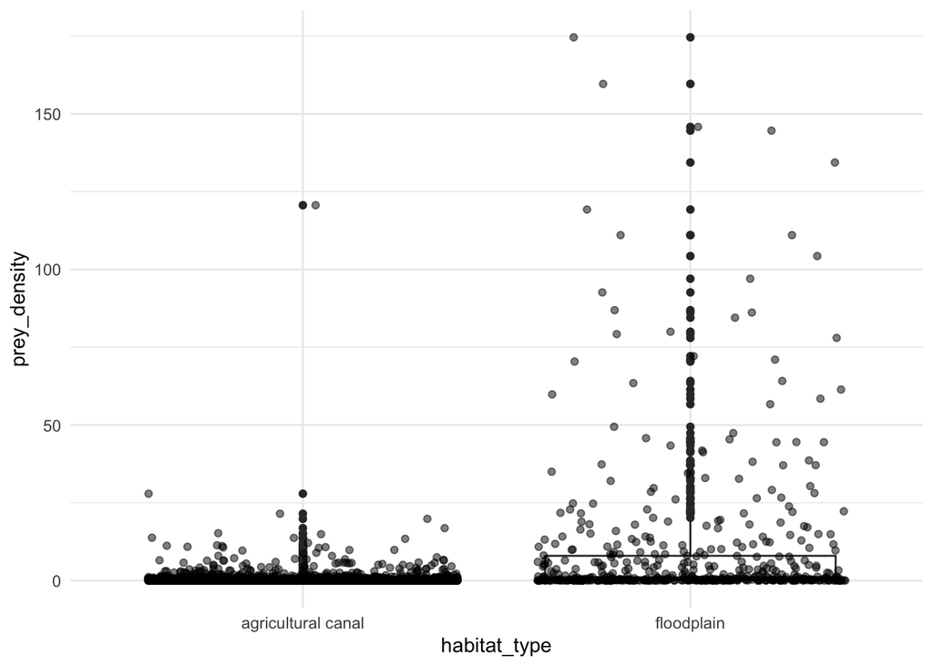

```r
ggplot(cordoleani_zoop, aes(y = prey_density, x = habitat_type)) +
  geom_boxplot() +
  geom_jitter(alpha=0.5) +
  theme_minimal()
```

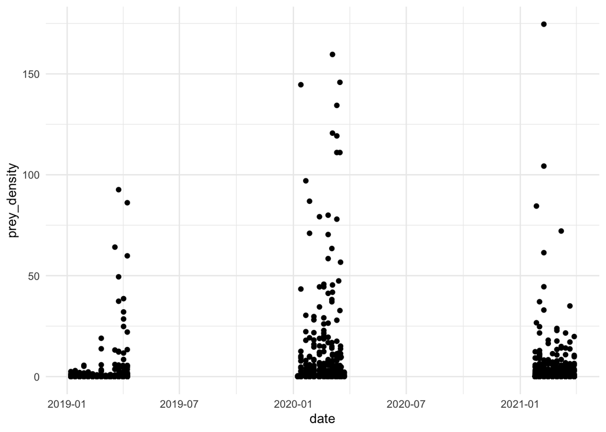

```r
ggplot(cordoleani_zoop, aes(x = date, y = prey_density)) +
  geom_point() +
  theme_minimal()
```

##### Fish Data:

```r
length(unique(cordoleani_fish$fish_id))
```

```
## [1] 295
```

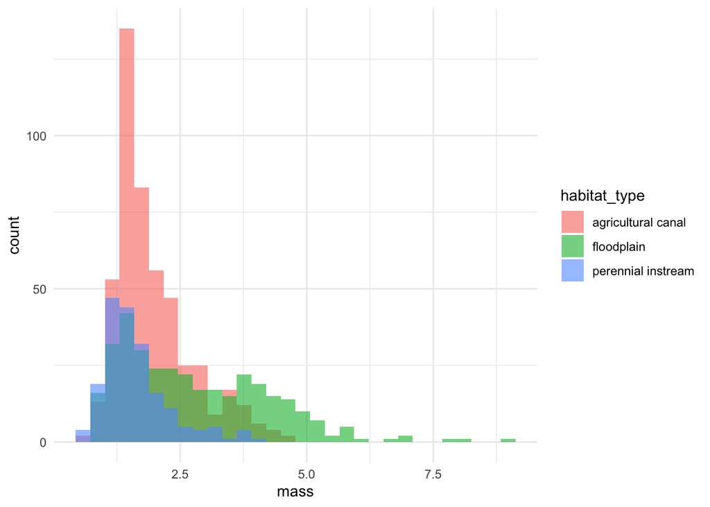

```r
ggplot(cordoleani_fish, aes(mass)) +
  geom_histogram(aes(fill = habitat_type), position = "identity", alpha = .6) +
  theme_minimal()
```

##### Environmental:

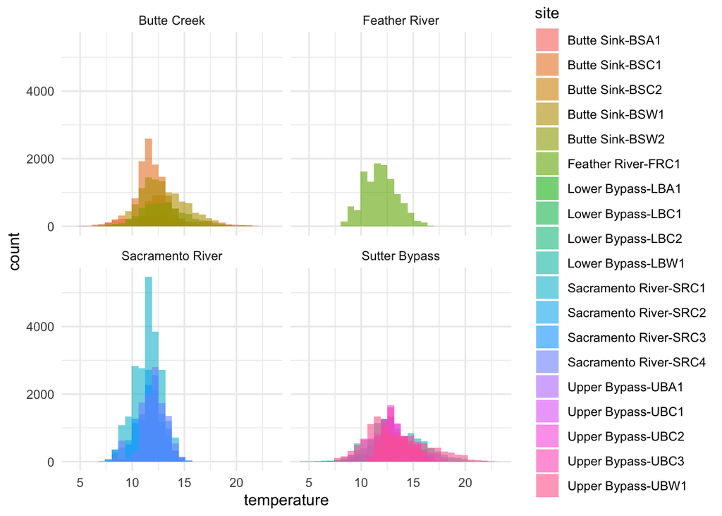

```r
ggplot(cordoleani_enviro, aes(x = temperature))+
  geom_histogram(aes(fill = site), position = "identity", alpha = .6) +
  facet_wrap(~watershed) +
  theme_minimal()
```

### Zeug - San Joaquin River

#### Load Raw Data

```r
raw_zoops <- read_excel("san-joaquin-steve-zeug/summary_zooplankton_10_19_17.xlsx",
                        sheet = "CountLiter2016",
                        range = "A1:H56")

kable(head(raw_zoops, 5))
```

| Year | Week | Reach | TaxGrp_1 | TotalTaxbyReach | ConcReachWeek | Sum of Volume | CountperVolume |
| --- | --- | --- | --- | --- | --- | --- | --- |
| 2016 | 1 | 1A | Microcrustacea | 559 | 1A-1 | 80.00 | 6.987500 |
| 2016 | 1 | 1A | Insecta-Diptera | 136 | 1A-1 | 80.00 | 1.700000 |
| 2016 | 2 | 1A | Microcrustacea | 35 | 1A-2 | 10.00 | 3.500000 |
| 2016 | 4 | 1A | Microcrustacea | 2568 | 1A-4 | 73.75 | 34.820339 |
| 2016 | 4 | 1A | Insecta-Diptera | 141 | 1A-4 | 73.75 | 1.911864 |

#### Data Standardization

```r
merced_sanJoaquin_zoops <- raw_zoops %>%
  rename(sample_id = Reach,
         species = TaxGrp_1,
         count = TotalTaxbyReach,
         prey_density = CountperVolume) %>%# currently total prey/l
  select(sample_id, species, prey_density, Year, Week) %>%
  mutate(author = "Zeug",
         watershed = 'San Joaquin',
         site = sample_id,
         size_class = "micro",
         species = tolower(species),
         gear_type = "10 liter Schindler-Patalas",
         mesh_size = 64) %>%
  select(-sample_id)

sj_locations <- data.frame(
  site = c('1A', '2A', '4B-CS', '4B-ESB'),
  habitat_type = c('perennial instream', 'perennial instream', 'side channel',  'perennial instream'),
  lat = c(36.860461, 36.798219, 37.166257, 37.166817),
  lon = c(-119.847043, -120.16085, -120.619793, -120.631145)
)

merced_sanJoaquin_zoops <- merge(merced_sanJoaquin_zoops, sj_locations, by = "site")

kable(head(merced_sanJoaquin_zoops, 5))
```

| site | species | prey_density | Year | Week | author | watershed | size_class | gear_type | mesh_size | habitat_type | lat | lon |
| --- | --- | --- | --- | --- | --- | --- | --- | --- | --- | --- | --- | --- |
| 1A | microcrustacea | 6.987500 | 2016 | 1 | Zeug | San Joaquin | micro | 10 liter Schindler-Patalas | 64 | perennial instream | 36.86046 | -119.847 |
| 1A | insecta-diptera | 1.700000 | 2016 | 1 | Zeug | San Joaquin | micro | 10 liter Schindler-Patalas | 64 | perennial instream | 36.86046 | -119.847 |
| 1A | microcrustacea | 3.500000 | 2016 | 2 | Zeug | San Joaquin | micro | 10 liter Schindler-Patalas | 64 | perennial instream | 36.86046 | -119.847 |
| 1A | microcrustacea | 34.820339 | 2016 | 4 | Zeug | San Joaquin | micro | 10 liter Schindler-Patalas | 64 | perennial instream | 36.86046 | -119.847 |
| 1A | insecta-diptera | 1.911864 | 2016 | 4 | Zeug | San Joaquin | micro | 10 liter Schindler-Patalas | 64 | perennial instream | 36.86046 | -119.847 |

##### View locations

```r
sj_locations_sf <- st_as_sf(sj_locations, coords = c('lon', 'lat'))

# leaflet(sj_locations_sf) %>%
#   addEsriBasemapLayer(esriBasemapLayers$Imagery,
#                       autoLabels=TRUE, group = 'Esri Basemap') %>%
#   addMarkers(popup = ~paste0(sj_locations_sf$site, '; ', sj_locations_sf$habitat_type ))
```

#### Data Exploration:

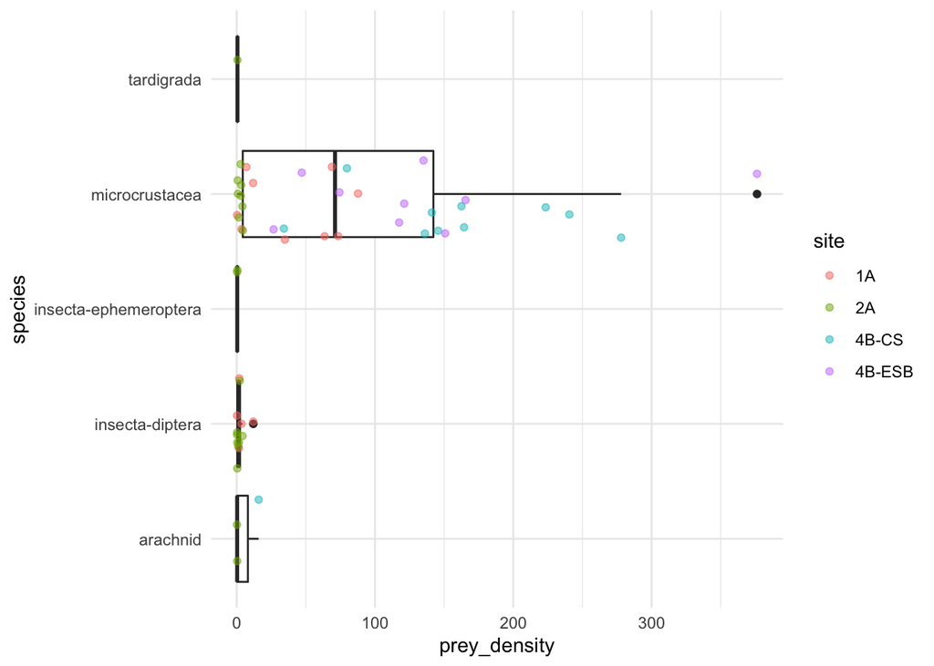

```r
ggplot(merced_sanJoaquin_zoops, aes(x = species, y = prey_density)) +
  geom_boxplot() +
  geom_jitter(alpha = 0.5, aes(color = site)) +
  coord_flip() +
  theme_minimal()
```

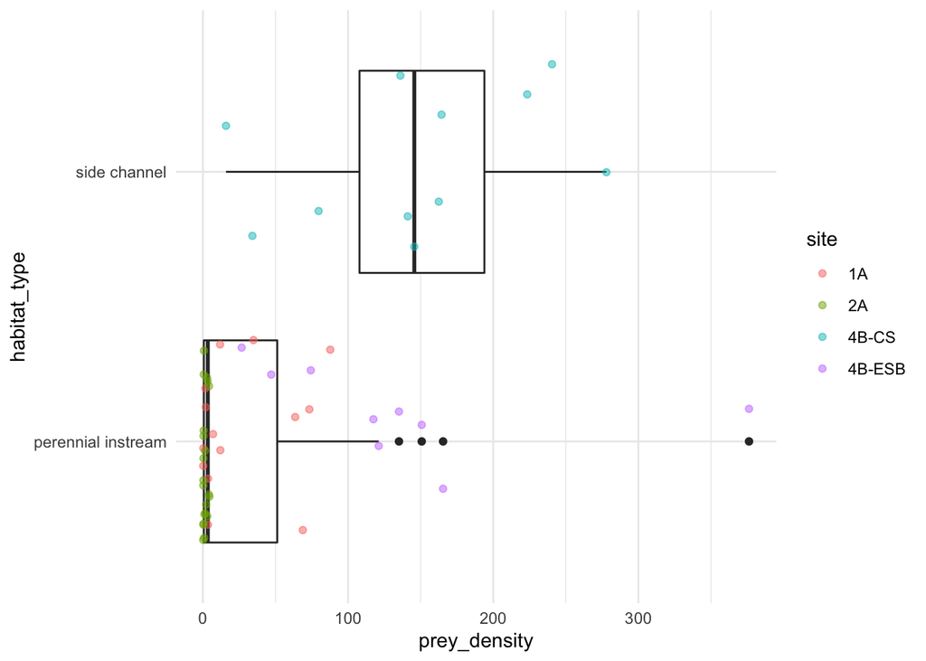

```r
ggplot(merced_sanJoaquin_zoops, aes(x = habitat_type, y = prey_density)) +
  geom_boxplot() +
  geom_jitter(alpha = 0.5, aes(color = site)) +
  coord_flip() +
  theme_minimal()
```

### Zeug - Merced River

#### Load Raw Data

##### Raw Prey Data

```r
raw_df <- read_excel("merced-steve-zeug/Merced invert data_environment.xls", .name_repair = 'minimal', sheet = "erin_modified",  col_names = FALSE)

dates <- janitor::excel_numeric_to_date(as.numeric(raw_df[1,3:ncol(raw_df)]), date_system = 'mac pre-2011') %>% as.character()

sites <- raw_df[2, 3:ncol(raw_df)]

col_names <- append(
  c('Species', 'Measurement'),
  paste(dates, sites, sep = '__')
)

names(raw_df) <- col_names

# view subset of data
kable(head(raw_df, 10))
```

| Species | Measurement | 2009-04-04__21 Drift | 2009-04-04__21 Benthic #1 | 2009-04-04__21 Benthic #2 | 2009-04-04__UN4 Benthic #2 | 2009-04-04__Drift UN4 | 2009-04-04__Drift 6 | 2009-04-04__Drift UN1 | 2009-04-09__6 Benthic #1 | 2009-04-09__6 Benthic #2 | 2009-04-09__UN4 Benthic #1 | 2009-04-04__UN1 Benthic #1 | 2009-04-09__UN1 Benthic #2 |
| --- | --- | --- | --- | --- | --- | --- | --- | --- | --- | --- | --- | --- | --- |
| NA | Date | 38445 | 38445 | 38445 | 38445 | 38445 | 38445 | 38445 | 38450 | 38450 | 38450 | 38445 | 38450 |
| NA | Site | 21 Drift | 21 Benthic #1 | 21 Benthic #2 | UN4 Benthic #2 | Drift UN4 | Drift 6 | Drift UN1 | 6 Benthic #1 | 6 Benthic #2 | UN4 Benthic #1 | UN1 Benthic #1 | UN1 Benthic #2 |
| NA | Subs | 1 | 2 | 1 | 1 | 1 | 1 | 1 | 2 | 1 | 1 | 2 | 2 |
| NA | Mfactor | 30 | 15 | 30 | 30 | 30 | 30 | 30 | 15 | 30 | 30 | 15 | 15 |
| Mayfly Adult | No. subsam | 12 | 0 | 0 | 0 | 4 | 18 | 1 | 8 | 0 | 0 | 0 | 0 |
| NA | No. scan | 0 | 0 | 0 | 0 | 0 | 0 | 0 | 0 | 0 | 0 | 0 | 0 |
| NA | No. m-2 (subsam) | 360 | 0 | 0 | 0 | 120 | 540 | 30 | 120 | 0 | 0 | 0 | 0 |
| NA | Tin | 1 | 0 | 0 | 0 | 111 | 118 | 109 | 123 | 0 | 0 | 0 | 0 |
| NA | Pre | 0.99665999999999999 | 0 | 0 | 0 | 1.0088699999999999 | 1.01973 | 0.99556999999999995 | 1.00701 | 0 | 0 | 0 | 0 |
| NA | Post | 0.99990999999999997 | 0 | 0 | 0 | 1.0101199999999999 | 1.02475 | 0.99575000000000002 | 1.0113700000000001 | 0 | 0 | 0 | 0 |

##### Raw Fish Data

```r
raw_salmon <- read_excel("merced-steve-zeug/salmon data_final(Josie).xlsx", skip = 2)

kable(head(raw_salmon, 5))
```

| fish # | Location | Length of Fish (cm) | Weight of fish (g) | Otolith code | Isotope Code | Tin Weight (pre-weight) | Tin Weight ( w/dried contents) | Tin Weight (combusted weight) | f: acarina | unknown ararchnid | baetis | chironomid larva | chironomid pupa | culoptila | unidentified egg | hydropsyche | f: hydroptilidae | f: asellidae | wormaldia | unknown adult terrestrial insect | adult beetle | unknown pupa | f: simulidae | seratella | f: tricorythidae | o: amphipoda | f: heptageineidae | hyrdo adult | hydro pupa | … |
| --- | --- | --- | --- | --- | --- | --- | --- | --- | --- | --- | --- | --- | --- | --- | --- | --- | --- | --- | --- | --- | --- | --- | --- | --- | --- | --- | --- | --- | --- | --- |
| 1 | 2B | 7.80 | 5.72 | A1 | 131 | 0.9979 | 1.02190 | 0.99993 | NA | NA | NA | NA | NA | NA | NA | NA | NA | NA | NA | NA | NA | NA | NA | NA | NA | NA | NA | NA | NA | … |
| 2 | 2B | 6.60 | 3.70 | A2 | 134 | 0.9990 | 1.01866 | 1.00017 | NA | NA | 2 | NA | 7 | NA | NA | NA | NA | 1 | NA | 1 | NA | NA | NA | 2 | NA | NA | NA | NA | NA | … |
| 3 | 2B | 7.00 | 4.06 | A3 | 137 | 1.0243 | 1.05074 | 1.02615 | NA | NA | NA | NA | NA | NA | NA | NA | NA | NA | NA | NA | NA | NA | NA | 1 | 1 | NA | NA | NA | NA | … |
| 4 | 2B | 6.90 | 3.93 | A4 | 138 | 1.0117 | 1.03140 | 1.01369 | NA | NA | NA | NA | 1 | NA | NA | NA | NA | 1 | NA | 1 | NA | NA | NA | NA | NA | NA | NA | NA | NA | … |
| 5 | 2B | 7.25 | 5.17 | A5 | 139 | 1.0083 | 1.03889 | 1.01104 | NA | NA | 3 | NA | 5 | NA | NA | NA | NA | NA | NA | NA | NA | 2 | NA | 4 | NA | NA | NA | NA | NA | … |

##### Raw Temperature Data

```r
raw_temps <- read_excel("merced-steve-zeug/Temperature.xlsx", sheet = "Sheet1", range = "A1:U212") %>%
  mutate(date = as.Date(`date/time`)) %>%
  select(-difference, -`date/time`)

kable(head(raw_temps, 5))
```

| Month | 23 max | 23 min | 23 mean | 14 max | 14 min | 14 mean | 2b max | 2b min | 2b mean | UN-1 max | UN-1 min | UN-1 mean | UN4 max | UN4 min | UN4 mean | BW max | BW min | BW mean | date |
| --- | --- | --- | --- | --- | --- | --- | --- | --- | --- | --- | --- | --- | --- | --- | --- | --- | --- | --- | --- |
| 9 | 23.521 | 18.390 | 20.71896 | 23.184 | 18.390 | 20.56054 | 22.657 | 18.343 | 20.35733 | 22.034 | 18.533 | 20.75300 | 22.321 | 18.224 | 20.16454 | 24.944 | 22.369 | 23.79083 | 2008-09-05 |
| 9 | 23.761 | 18.723 | 21.02208 | 23.424 | 18.723 | 20.84854 | 22.896 | 18.652 | 20.62742 | 22.226 | 18.533 | 20.32029 | 22.537 | 18.509 | 20.41275 | 25.623 | 23.016 | 24.36021 | 2008-09-06 |
| 9 | 24.098 | 18.794 | 21.22742 | 23.737 | 18.794 | 21.04975 | 23.184 | 18.723 | 20.82346 | 22.513 | 18.628 | 20.51888 | 22.800 | 18.604 | 20.61046 | 25.647 | 23.376 | 24.65892 | 2008-09-07 |
| 9 | 23.833 | 18.699 | 21.04396 | 23.472 | 18.723 | 20.89708 | 22.920 | 18.699 | 20.69083 | 22.226 | 18.628 | 20.40237 | 22.537 | 18.580 | 20.47600 | 25.866 | 23.593 | 24.84313 | 2008-09-08 |
| 9 | 23.376 | 18.485 | 20.53963 | 23.088 | 18.485 | 20.41204 | 22.513 | 18.485 | 20.22287 | 21.533 | 18.366 | 19.92883 | 22.011 | 18.319 | 20.00433 | 25.137 | 23.136 | 24.19233 | 2008-09-09 |

#### Data Standardization

##### Prey Data Standardization

- `gear_type` was extracted from column name
- TO DO: check units for prey density. Currently using No. m-2 (subsam) and dividing by provided volume (m^3) and converting to count/L.

```r
merced_steve_zeug_zoop <- raw_df[3:nrow(raw_df),] %>%
  fill(Species, .direction = 'down') %>% #TODO make sure species is accurate(looks like fill is tricky with xlsx format)
  filter(Measurement == 'No. m-2 (subsam)') %>% # is this the value we want for prey density??
  pivot_longer(cols = !c('Species', 'Measurement'), names_to = "date__site") %>%
  separate(col = date__site, into = c('date', 'site'), sep = '__') %>%
  rename(prey_density = value, #TODO: what is this unit, No. m-2 (subsam) ??
        date = date,
         sample_id = site,
         species = Species) %>%
  mutate(author = 'Zeug',
         life_stage = ifelse(grepl('Adult', species), 'Adult',
                             ifelse(grepl('Larvae', species), 'Larvae',
                                    ifelse(grepl('Pupae', species), 'Pupae',
                                           ifelse(grepl('Nymph', species), 'Nymph', NA)))),
         gear_type = ifelse(grepl('Drift', sample_id), 'Drift',
                            ifelse(grepl('Benthic', sample_id), 'Benthic', NA))) %>%
  mutate(tmp_name = gsub('Drift', '', sample_id), # extract sample_id
         name = stringr::str_split(tmp_name, " ") %>% map_chr(., 1),
         sample_id = ifelse(name == '', tmp_name, name ),
         size_class = "macro",
         watershed = "Merced",
         gear_type = tolower(gear_type),
         life_stage = tolower(life_stage),
         species = tolower(species),
         habitat_type = "perennial instream") %>%
  select(-c(tmp_name, name)) %>%
  mutate(sample_id = gdata::trim(sample_id),
         mesh_size = 500) %>%
  filter(gear_type == "drift") %>%
  mutate(gear_type = "net throw") %>%
  glimpse
```

```
## Rows: 140
## Columns: 12
## $ species      <chr> "mayfly adult", "mayfly adult", "mayfly adult", "mayfly a…
## $ Measurement  <chr> "No. m-2 (subsam)", "No. m-2 (subsam)", "No. m-2 (subsam)…
## $ date         <chr> "2009-04-04", "2009-04-04", "2009-04-04", "2009-04-04", "…
## $ sample_id    <chr> "21", "UN4", "6", "UN1", "21", "UN4", "6", "UN1", "21", "…
## $ prey_density <chr> "360", "120", "540", "30", "2220", "1800", "2400", "3300"…
## $ author       <chr> "Zeug", "Zeug", "Zeug", "Zeug", "Zeug", "Zeug", "Zeug", "…
## $ life_stage   <chr> "adult", "adult", "adult", "adult", "adult", "adult", "ad…
## $ gear_type    <chr> "net throw", "net throw", "net throw", "net throw", "net …
## $ size_class   <chr> "macro", "macro", "macro", "macro", "macro", "macro", "ma…
## $ watershed    <chr> "Merced", "Merced", "Merced", "Merced", "Merced", "Merced…
## $ habitat_type <chr> "perennial instream", "perennial instream", "perennial in…
## $ mesh_size    <dbl> 500, 500, 500, 500, 500, 500, 500, 500, 500, 500, 500, 50…
```

```r
# Load in volumns sampled from seperate xlsx sheet and use it to calculated count/L
vols <- readxl::read_excel('merced-steve-zeug/Flow_meter_Drift.xlsx', skip = 4) %>%
  janitor::clean_names()

vols <- vols %>% select(site, corrected_voume_m3_s_1) %>%
  filter(!is.na(corrected_voume_m3_s_1))

merced_steve_zeug_zoop <- merge(merced_steve_zeug_zoop, vols, by.y = "site", by.x = "sample_id" )

merced_steve_zeug_zoop <- merced_steve_zeug_zoop %>%
  mutate(prey_density = as.numeric(prey_density)/corrected_voume_m3_s_1/1000, # convert from m^3 to L
         date = as.Date(date)) %>%
  rename(site = sample_id) %>%
  select(-corrected_voume_m3_s_1, -Measurement)

kable(head(merced_steve_zeug_zoop, 5))
```

| site | species | date | prey_density | author | life_stage | gear_type | size_class | watershed | habitat_type | mesh_size |
| --- | --- | --- | --- | --- | --- | --- | --- | --- | --- | --- |
| 21 | mayfly adult | 2009-04-04 | 0.0009849 | Zeug | adult | net throw | macro | Merced | perennial instream | 500 |
| 21 | unknown fish larvae | 2009-04-04 | 0.0000027 | Zeug | larvae | net throw | macro | Merced | perennial instream | 500 |
| 21 | c: arachnida | 2009-04-04 | 0.0000821 | Zeug | NA | net throw | macro | Merced | perennial instream | 500 |
| 21 | unidentified ant | 2009-04-04 | 0.0006566 | Zeug | NA | net throw | macro | Merced | perennial instream | 500 |
| 21 | chironomidae adult | 2009-04-04 | 0.0060738 | Zeug | adult | net throw | macro | Merced | perennial instream | 500 |

##### Fish Data Standardization

- One outlier of 70 cm fish length removed from dataset
- converted `fork_length` from centimeters to millimeters
- removed columns `otolith code`, `isotope code`, and columns related to `tin weights` .
- also removed all fish consumption data. This could easily be folded back in, unsure if it is necessary. [see commented out section]

```r
merced_steve_zeug_fish <- raw_salmon %>%
  filter(`Length of Fish (cm)` < 70) %>% # removes outlier
  rename(fish_id = `fish #`,
         site = Location,
         fork_length = `Length of Fish (cm)`,
         mass = `Weight of fish (g)`) %>%
  mutate(fork_length = fork_length * 10, # converts from cm to mm
         author = 'Zeug',
         watershed = 'Merced') %>%
  select(-c(`Otolith code`:comments))

kable(head(merced_steve_zeug_fish, 5))
```

| fish_id | site | fork_length | mass | author | watershed |
| --- | --- | --- | --- | --- | --- |
| 1 | 2B | 78.0 | 5.72 | Zeug | Merced |
| 2 | 2B | 66.0 | 3.70 | Zeug | Merced |
| 3 | 2B | 70.0 | 4.06 | Zeug | Merced |
| 4 | 2B | 69.0 | 3.93 | Zeug | Merced |
| 5 | 2B | 72.5 | 5.17 | Zeug | Merced |

##### Temperature Data Standardization

- Used average temperature instead of min, max

```r
merced_steve_zeug_temp <- raw_temps %>%
  pivot_longer(cols = `23 max`:`BW mean`) %>%
  separate(name, into = c("site", "measurement"), sep = " ") %>%
  rename(temperature = value,
         #sample_id = site,
         date = date) %>%
  filter(measurement == 'mean') %>%
  select(-Month, -measurement) %>%
  mutate(author = 'Zeug',
         watershed = 'Merced')

kable(head(merced_steve_zeug_temp, 5))
```

| date | site | temperature | author | watershed |
| --- | --- | --- | --- | --- |
| 2008-09-05 | 23 | 20.71896 | Zeug | Merced |
| 2008-09-05 | 14 | 20.56054 | Zeug | Merced |
| 2008-09-05 | 2b | 20.35733 | Zeug | Merced |
| 2008-09-05 | UN-1 | 20.75300 | Zeug | Merced |
| 2008-09-05 | UN4 | 20.16454 | Zeug | Merced |

### Guignard - Stanislaus

#### Load Raw Data

##### Raw Prey Data

- created a modified version of the tab *Density by location, date…* to make it easier to load into R

```r
stanislaus_zoop_raw <- read_excel("stanislaus-jason-guignard/Honolulu Bar data.xlsx",
                                  sheet = 'Density by location, date,ta_MR')

kable(head(stanislaus_zoop_raw, 5))
```

| Location | Date | Total Drift Density | Ephemeroptera | Plecoptera | Tricoptera | Diptera | Microcrustacea | Other Taxa |
| --- | --- | --- | --- | --- | --- | --- | --- | --- |
| Main Channel | 2014-04-04 | 0.668 | 0.0841751 | 0.0000000 | 0.0026305 | 0.4235059 | 0.0894360 | 0.0682525 |
| Main Channel | 2014-04-14 | 0.347 | 0.0157332 | 0.0043703 | 0.0034963 | 0.0332145 | 0.0825991 | 0.2075867 |
| Main Channel | 2014-05-01 | 0.818 | 0.0200706 | 0.0000000 | 0.0000000 | 0.0441554 | 0.6543031 | 0.0994708 |
| Main Channel | 2014-05-09 | 0.970 | 0.0480584 | 0.0000000 | 0.0240292 | 0.2450980 | 0.2883506 | 0.3644637 |
| Main Channel | 2014-05-13 | 0.742 | 0.0428873 | 0.0000000 | 0.0098971 | 0.1715492 | 0.3562945 | 0.1613719 |

##### Raw Temperature Data

```r
stanislaus_temp_data_raw <- read_excel("stanislaus-jason-guignard/Honolulu Bar data.xlsx",
                                       sheet = 'FlowTemp')

kable(head(stanislaus_temp_data_raw, 5))
```

| Time | Temp F | Flow cfs |
| --- | --- | --- |
| 2014-04-01 | 54.2 | 244 |
| 2014-04-02 | 54.8 | 248 |
| 2014-04-03 | 55.5 | 243 |
| 2014-04-04 | 55.7 | 234 |
| 2014-04-05 | 56.1 | 233 |

##### Location Data

- Changed .kmz tile to .kml for simplified loading into R

```r
locations <- st_read(dsn = 'stanislaus-jason-guignard/drift net sites_to_kml.kml')
# add lat and long columns based on geometry
locations <- locations %>%
  dplyr::mutate(lon = sf::st_coordinates(.)[,1],
                lat = sf::st_coordinates(.)[,2])

#kable(locations)
```

#### Data Standardization

##### Prey Data Standardization

```r
stanislaus_zoop <- stanislaus_zoop_raw %>%
  rename(location = Location,
         prey_density_total = `Total  Drift Density`,# units are cubic feet
         other_taxa = `Other Taxa`) %>%
  mutate(prey_density_total = prey_density_total/28.3168) %>%  #1ft^3 = 28.3168 Liters  # this is the sum of all species
  gather(!c('location', 'prey_density_total', 'Date'), key = species, value = value )%>%
  mutate(author = 'Guignard',
         watershed = 'Stanislaus',
         species = tolower(species)) %>%
  rename(prey_density = value,
         date = Date) %>%
  mutate(prey_density = prey_density/0.0283168,
         site = location,
         gear_type = "net throw",
         mesh_size = 335,
         size_class = "meso/macro") %>% # size class is 335 micrometer mesh.
  select(-prey_density_total, -location)

kable(head(stanislaus_zoop, 5))
```

| date | species | prey_density | author | watershed | site | gear_type | mesh_size | size_class |
| --- | --- | --- | --- | --- | --- | --- | --- | --- |
| 2014-04-04 | ephemeroptera | 2.9726199 | Guignard | Stanislaus | Main Channel | net throw | 335 | meso/macro |
| 2014-04-14 | ephemeroptera | 0.5556124 | Guignard | Stanislaus | Main Channel | net throw | 335 | meso/macro |
| 2014-05-01 | ephemeroptera | 0.7087894 | Guignard | Stanislaus | Main Channel | net throw | 335 | meso/macro |
| 2014-05-09 | ephemeroptera | 1.6971706 | Guignard | Stanislaus | Main Channel | net throw | 335 | meso/macro |
| 2014-05-13 | ephemeroptera | 1.5145534 | Guignard | Stanislaus | Main Channel | net throw | 335 | meso/macro |

##### Location Data Standardization

- Match names of locations to the `stanislaus_zoop` table and merge them
- Manually assign `habitat_type` using best professional judgement

```r
# locaton names of zoop data
unique(stanislaus_zoop$site)
```

```
## [1] "Main Channel"       "Top Side"           "Lower Side"
## [4] "Lower Flood Plain"  "Middle Flood Plain" "Upper Flood Plain"
```

```r
# location names in .kmz
unique(locations$Name)
```

```
## [1] "H Bar Main Channel"           "Floodplain Lower"
## [3] "Floodplain Upper"             "Side Channel Lower"
## [5] "Side Channel Upper"           "Middle Floodplain"
## [7] "H Bar main abv. side channel"
```

```r
# change the names of the locations dataset to match those in in the zoops table
locations[locations$Name == "H Bar Main Channel", 'Name'] <- 'Main Channel'
locations[locations$Name == "Side Channel Upper", 'Name'] <- 'Top Side'
locations[locations$Name == "Side Channel Lower", 'Name'] <- 'Lower Side'
locations[locations$Name == "Floodplain Upper", 'Name'] <- 'Upper Flood Plain'
locations[locations$Name == "Middle Floodplain", 'Name'] <- 'Middle Flood Plain'
locations[locations$Name == "Floodplain Lower", 'Name'] <- 'Lower Flood Plain'

locations <- locations %>%
  mutate(habitat_type = ifelse(Name %in% c('Main Channel'), 'perennial instream',
                               ifelse(Name %in% c('Top Side', 'Lower Side'), 'side channel',
                                      ifelse(Name %in% c('Upper Flood Plain', 'Middle Flood Plain', 'Lower Flood Plain'), 'floodplain', NA)))
  ) %>%
  rename(site = Name)

# leaflet(locations) %>%
#   addEsriBasemapLayer(esriBasemapLayers$Imagery,
#                       autoLabels=TRUE, group = 'Esri Basemap') %>%
#   addMarkers(popup = ~paste0(locations$site, ' ', locations$habitat_type ))
```

##### Temperature Data Standardization

```r
stanislaus_temp_data <- stanislaus_temp_data_raw %>%
  mutate(author = 'Guignard',
         watershed = 'Stanislaus') %>%
  rename(date = Time,
         flow_cfs = `Flow cfs`,
         temperature = `Temp F`)
```

##### Combine location and prey datasets

```r
stanislaus_zoop <- merge(stanislaus_zoop, locations, by = 'site') %>%
  select(-Description)
```

### Montgomery

#### Load Raw Data

- Data is currently located on EDI repository and downloaded directly into R

##### Raw Prey Data

```r
# zoops_table comes directly from EDI

kable(head(zoops_table, 5))
```

| id | pseudodiptomus_adult | psedodiptomus_copepidite | acanthocyclops_adult | acanthocyclops_copepididte | cyclopoid_sp | cyclopoid_nauplii | calanoid_naulpii | harpaticoid | daphnia_pulex | daphnia_laevis | daphnia_magna | daphnia_mendotea | ceriodaphnia_sp | simocephalus_sp | bosmina_sp | sididae | chydorus_sphaericus | eurycercus | alona | chydoridae | diaphanosoma | scapholeberis | cladocera_embryo | eucypris | ilyocypris | cypridopsis | gammarus | rotifer | polychaete | … |
| --- | --- | --- | --- | --- | --- | --- | --- | --- | --- | --- | --- | --- | --- | --- | --- | --- | --- | --- | --- | --- | --- | --- | --- | --- | --- | --- | --- | --- | --- | --- |
| MNT3ASource_10/1/2018_8:00 | 0 | 0.00000 | 0.000000 | 19.80595 | 0 | 0.000000 | 0.000000 | 0.000000 | 11.31768 | 0 | 0 | 0 | 5.658842 | 0.00000 | 8.488264 | 0 | 2.829421 | 0 | 2.829421 | 0 | 0 | 0 | 16.976527 | 0.000000 | 0.000000 | 0.00000 | 0.00000 | 0.00000 | 0 | … |
| MNTNEWCAN_4/8/2019_8:25 | 0 | 11.31768 | 2.829421 | 178.25354 | 0 | 5.658842 | 5.658842 | 0.000000 | 0.00000 | 0 | 0 | 0 | 73.564952 | 0.00000 | 22.635370 | 0 | 246.159645 | 0 | 59.417845 | 0 | 0 | 0 | 5.658842 | 5.658842 | 0.000000 | 11.31768 | 0.00000 | 48.10016 | 0 | … |
| ACCSAC2_11/5/2018_12:30 | 0 | 14.63494 | 126.836123 | 1170.35150 | 0 | 0.000000 | 121.957811 | 9.756625 | 0.00000 | 0 | 0 | 0 | 439.048119 | 19.51325 | 204.889122 | 0 | 282.942121 | 0 | 29.269875 | 0 | 0 | 0 | 97.566249 | 0.000000 | 9.756625 | 0.00000 | 19.51325 | 411.55218 | 0 | … |
| ELDCAN_4/8/2019_11:40 | 0 | 0.00000 | 8.488264 | 234.84196 | 0 | 0.000000 | 2.829421 | 0.000000 | 14.14711 | 0 | 0 | 0 | 8.488264 | 0.00000 | 11.317685 | 0 | 53.759003 | 0 | 5.658842 | 0 | 0 | 0 | 0.000000 | 0.000000 | 0.000000 | 0.00000 | 0.00000 | 31.12363 | 0 | … |
| MNTNEWCAN_4/1/2019_8:20 | 0 | 0.00000 | 169.765274 | 848.82637 | 0 | 84.882637 | 0.000000 | 0.000000 | 0.00000 | 0 | 0 | 0 | 254.647911 | 0.00000 | 0.000000 | 0 | 9676.620636 | 0 | 1103.474283 | 0 | 0 | 0 | 169.765274 | 169.765274 | 0.000000 | 84.88264 | 0.00000 | 679.06110 | 0 | … |

```r
# caged_fish comes directly from EDI

kable(head(caged_fish, 5))
```

| Date | LOCATION | PIT | Length.mm | Weight.g |
| --- | --- | --- | --- | --- |
| 2/21/2019 | ELDSAC | B03F5 | 52 | 1.45 |
| 2/21/2019 | ELDSAC | B040B | 44 | 0.85 |
| 2/21/2019 | ELDSAC | B0410 | 47 | 1.22 |
| 2/21/2019 | ELDSAC | B0425 | 48 | 1.01 |
| 2/21/2019 | ELDSAC | B0439 | 47 | 1.02 |

##### Raw Temperature Data

- this is extracted from the `zoops_table`

#### Data Standardization

##### Prey & Temperature Data Standardization

- extracted temperature and dissolved oxygen from zooplankton data. `site` should link the two datasets.
- Converted from count/m^3 to count/L

```r
montgomery_zoop_tmp <- zoops_table %>%
  separate(id, c('location', 'Date'), '_') %>%
  mutate(date = mdy(Date)) %>%
  gather(!c('location', 'Date', 'date':'volume_sampled'), key = species, value = value) %>%
  separate(species, c('species', 'life_stage'), '_') %>%
  select(-c(Date, ec_s_cm:do_sat, p_h:volume_sampled)) %>%
  rename(temperature = temp_c,
         prey_density = value) %>%
  mutate(author = "Montgomery",
         site = location,
         size_class = "meso",
         gear_type = "net throw",
         mesh_size = 150,
         prey_density = prey_density/1000) #1 m^3 = 1000 L


# extract out temperature, do
montgomery_temp <- montgomery_zoop_tmp %>%
  select(date, site, temperature, do_mg_l, author)

# extract out relevant zoop data and filter to relevant prey_density
montgomery_zoop <- montgomery_zoop_tmp %>%
  select(date, site, species:author, size_class, mesh_size, gear_type) %>%
  filter(prey_density > 0)

kable(head(montgomery_zoop, 5))
```

| date | site | species | life_stage | prey_density | author | size_class | mesh_size | gear_type |
| --- | --- | --- | --- | --- | --- | --- | --- | --- |
| 2019-04-15 | MNTNEWCAN | pseudodiptomus | adult | 0.0056588 | Montgomery | meso | 150 | net throw |
| 2019-04-15 | KNG6 | pseudodiptomus | adult | 0.2829421 | Montgomery | meso | 150 | net throw |
| 2018-11-05 | MNTNEWCAN2 | pseudodiptomus | adult | 0.4951487 | Montgomery | meso | 150 | net throw |
| 2019-02-04 | ACCSAC4 | pseudodiptomus | adult | 0.0032153 | Montgomery | meso | 150 | net throw |
| 2019-03-10 | KNGCAN | pseudodiptomus | adult | 0.1768388 | Montgomery | meso | 150 | net throw |

```r
kable(head(montgomery_temp, 5))
```

| date | site | temperature | do_mg_l | author |
| --- | --- | --- | --- | --- |
| 2018-10-01 | MNT3ASource | 18.563 | 3.89 | Montgomery |
| 2019-04-08 | MNTNEWCAN | 18.512 | 9.20 | Montgomery |
| 2018-11-05 | ACCSAC2 | 15.000 | 10.09 | Montgomery |
| 2019-04-08 | ELDCAN | 13.262 | 10.33 | Montgomery |
| 2019-04-01 | MNTNEWCAN | 17.270 | 9.17 | Montgomery |

##### Raw Locations Data

- downloaded locations data from EDI and manually assigned each habitat type based on best professional judgement

```r
# write.csv(location_lookup, 'mont_locations.csv')
montgomery_locations <- read.csv('mont_locations.csv') %>%
  rename(site = location,
         watershed = stream)

kable(head(montgomery_locations, 5))
```

| site | habitat_type | lon | lat | watershed | notes |
| --- | --- | --- | --- | --- | --- |
| ACC | agricultural canal | -121.6043 | 38.78183 | Sacramento River | cross canal |
| ACCSAC1 | perennial instream | -121.6078 | 38.78170 | Sacramento River |  |
| ACCSAC2 | perennial instream | -121.6020 | 38.77818 | Sacramento River |  |
| ACCSAC3 | perennial instream | -121.5984 | 38.77412 | Sacramento River |  |
| ACCSAC4 | perennial instream | -121.5936 | 38.76663 | Sacramento River |  |

##### Fish Data Standardization

```r
montgomery_fish <- caged_fish %>%
  rename(site = LOCATION,
         fish_id = PIT,
         fork_length = Length.mm,
         mass = Weight.g,
         date = Date) %>%
  mutate(date = as_date(mdy(date)),
         author = "Montgomery")

kable(head(montgomery_fish, 5))
```

| date | site | fish_id | fork_length | mass | author |
| --- | --- | --- | --- | --- | --- |
| 2019-02-21 | ELDSAC | B03F5 | 52 | 1.45 | Montgomery |
| 2019-02-21 | ELDSAC | B040B | 44 | 0.85 | Montgomery |
| 2019-02-21 | ELDSAC | B0410 | 47 | 1.22 | Montgomery |
| 2019-02-21 | ELDSAC | B0425 | 48 | 1.01 | Montgomery |
| 2019-02-21 | ELDSAC | B0439 | 47 | 1.02 | Montgomery |

##### Locations standardization

- used lat/long to assign geometry for each sampling location
- manually assigned each `habitat_type`. Click on marker to see description in map below.

```r
# create a simple feature
montgomery_locations_sf <- st_as_sf(montgomery_locations, coords = c('lon', 'lat'))

# leaflet(montgomery_locations_sf) %>%
#   addEsriBasemapLayer(esriBasemapLayers$Imagery, autoLabels=TRUE, group = 'Esri Basemap') %>%
#   addMarkers(popup = ~paste0(montgomery_locations_sf$site, ' ', montgomery_locations_sf$habitat_type ))
```

##### Combine locations with zoops data

```r
montgomery_zoop <- merge(montgomery_zoop, montgomery_locations, by = "site")

montgomery_zoop <- montgomery_zoop %>%
  select(-notes)

montgomery_fish <- merge(montgomery_fish, montgomery_locations, by = "site") %>%
  select(-notes)
```

### Zooper R library

- download data from Zooper library [[Intergency Ecological Program](https://github.com/InteragencyEcologicalProgram/zooper)]
- convert from count/m^3 to count/L
- extract `temperature` into unique environmental dataset

```r
# zoop_data <- Zoopsynther(Data_type = "Community",
#                        Sources = c("EMP", "FRP",
#                                    "FMWT", "STN", "20mm"),
#                        Size_class = c("Micro", "Meso", "Macro"),
#                        Date_range = c("1990-10-01", "2020-09-30"))

#saveRDS(zoop_data, 'zoop_data.rds')
zoop_data <- readRDS('zoop_data.rds')

zooper <- zoop_data %>%
  select(date = Date, prey_per_unit_volume = CPUE, species = Taxname, life_stage = Lifestage,
         size_class = SizeClass, author = Source, site = SampleID,
         temperature = Temperature, lat = Latitude, lon = Longitude) %>%
  mutate(author = paste0('zooper: ', author),
         species = tolower(species),
         size_class = tolower(size_class),
         life_stage = tolower(life_stage),
         prey_density = prey_per_unit_volume/1000)  # convert to count/L from count/m^3


# Add in categorization of North Delta or South Delta
# Adds polygon for each site
delta_extents <- rgdal::readOGR("../data-raw/shape_files/delta_extents/HabitatExtentsForCorreigh.shp") %>%
  st_as_sf(coords = c("longitude", "latitude"), dim = "XY", crs = 4326) %>%
  st_transform("WGS84")
```

```r
# Maps sites, monitoring locations, and corresponding polygons
# leaflet() %>%
#   addTiles() %>%
#   addPolygons(data = delta_extents, label = ~watershed)

sf_zooper_points <- st_as_sf(zooper %>% filter(!is.na(lon), !is.na(lat)), coords = c('lon', 'lat'), crs = 4326, remove = FALSE)

zooper_with_watershed <- st_join(delta_extents, sf_zooper_points) %>%
  st_set_geometry(NULL) %>%
  glimpse()
```

```
## Rows: 596,833
## Columns: 13
## $ Id                   <int> 0, 0, 0, 0, 0, 0, 0, 0, 0, 0, 0, 0, 0, 0, 0, 0, 0…
## $ watershed            <chr> "Yolo Bypass 1", "Yolo Bypass 2", "Yolo Bypass 2"…
## $ date                 <dttm> NA, 2012-10-18, 2017-11-13, 2017-11-13, 2017-11-…
## $ prey_per_unit_volume <dbl> NA, 150.67, 0.07, 0.30, 1.79, 0.22, 13.43, 0.03, …
## $ species              <chr> NA, "hyperacanthomysis longirostris", "americorop…
## $ life_stage           <chr> NA, "adult", "adult", "adult", "adult", "adult", …
## $ size_class           <chr> NA, "macro", "macro", "macro", "macro", "macro", …
## $ author               <chr> NA, "zooper: FMWT", "zooper: FMWT", "zooper: FMWT…
## $ site                 <chr> NA, "FMWT 719 2012-10-18", "FMWT 719 2017-11-13",…
## $ temperature          <dbl> NA, 18.6, 15.3, 15.3, 15.3, 15.3, 15.3, 10.8, 10.…
## $ lat                  <dbl> NA, 38.33428, 38.33428, 38.33428, 38.33428, 38.33…
## $ lon                  <dbl> NA, -121.6473, -121.6473, -121.6473, -121.6473, -…
## $ prey_density         <dbl> NA, 0.15067, 0.00007, 0.00030, 0.00179, 0.00022, …
```

```r
# extract temperature
zooper_temperature <- zooper %>%
  select(date, temperature, author, site, lat, lon)

zooper_prey_data <- zooper_with_watershed %>%
    select(-Id, -prey_per_unit_volume, -temperature) %>%
    filter(!is.na(author)) # filter out watershed designations with no intersection

kable(head(zooper_prey_data, 5))
```

|  | watershed | date | species | life_stage | size_class | author | site | lat | lon | prey_density |
| --- | --- | --- | --- | --- | --- | --- | --- | --- | --- | --- |
| 1 | Yolo Bypass 2 | 2012-10-18 | hyperacanthomysis longirostris | adult | macro | zooper: FMWT | FMWT 719 2012-10-18 | 38.33428 | -121.6473 | 0.15067 |
| 1.1 | Yolo Bypass 2 | 2017-11-13 | americorophium spinicorne | adult | macro | zooper: FMWT | FMWT 719 2017-11-13 | 38.33428 | -121.6473 | 0.00007 |
| 1.2 | Yolo Bypass 2 | 2017-11-13 | americorophium stimpsoni | adult | macro | zooper: FMWT | FMWT 719 2017-11-13 | 38.33428 | -121.6473 | 0.00030 |
| 1.3 | Yolo Bypass 2 | 2017-11-13 | gammarus_unid | adult | macro | zooper: FMWT | FMWT 719 2017-11-13 | 38.33428 | -121.6473 | 0.00179 |
| 1.4 | Yolo Bypass 2 | 2017-11-13 | hyalella_unid | adult | macro | zooper: FMWT | FMWT 719 2017-11-13 | 38.33428 | -121.6473 | 0.00022 |

```r
kable(head(zooper_temperature, 5))
```

| date | temperature | author | site | lat | lon |
| --- | --- | --- | --- | --- | --- |
| 2015-03-12 | 15.7 | zooper: EMP | EMP NZ092 2015-03-12 | 37.97833 | -121.3819 |
| 2015-03-12 | 15.7 | zooper: EMP | EMP NZ092 2015-03-12 | 37.97833 | -121.3819 |
| 2015-03-12 | 15.7 | zooper: EMP | EMP NZ092 2015-03-12 | 37.97833 | -121.3819 |
| 2015-03-12 | 15.7 | zooper: EMP | EMP NZ092 2015-03-12 | 37.97833 | -121.3819 |
| 2015-03-12 | 15.7 | zooper: EMP | EMP NZ092 2015-03-12 | 37.97833 | -121.3819 |

# Size Class Methodology

*Mesh size availability by dataset* to inform size class definition

| Dataset | Mesh Size | Gear Type | Life Stage | Other Species Info |
| --- | --- | --- | --- | --- |
| Cordoleani | 30 cm diameter 150 µm mesh | Net Throw |  |  |
| Corline | 153-154 Mesh Size (microns) | Net Throw | adult, nauplii, juevenile, embryo, egg, larvae, pupae, nympth | By column: Phylum, Subclass, Order, Family, Genus, Species |
| Steve Zeug - San Joaquin | 64 micron mesh | 10 liter Schindler-Patalas | NA | species (group): Microcrustacea, Insecta-Diptera, Arachnid, Tardigrada, Insecta-Ephemeroptera |
| Stanislaus | 335 micrometer mesh; 1 sqft opening | drift net | NA | By column, species Order: Ephemeroptera, Plecoptera, Tricoptera, Diptera, Microcrustacea, Other Taxa |
| Montgomery | 30-cm diameter x 150 µm mesh | Net Tow | adult, sphaericus, sp, embryo, copepididte, pulex, nauplii, copepidite, mendotea, magna, insect, naulpii, larvae | species |
| Steve Zeug - Merced | 47 x 28 cm diameter; 500 micron mesh size |  |  |  |

# Combine All Datasets

## Prey Data

### Combine Prey Data

```r
all_prey <- bind_rows(cordoleani_zoop,
                      corline_zoop,
                      merced_sanJoaquin_zoops,
                      zooper_prey_data,
                      merced_steve_zeug_zoop,
                      montgomery_zoop,
                      stanislaus_zoop) %>%
  #select(-geometry, -Year, -Week) %>%
  mutate(watershed = ifelse(watershed == "Feather River ", "Feather River", watershed))

kable(head(all_prey, 10))
```

|  | site | habitat_type | date | species | prey_density | author | watershed | size_class | gear_type | mesh_size | lat | lon | life_stage | Year | Week | geometry |
| --- | --- | --- | --- | --- | --- | --- | --- | --- | --- | --- | --- | --- | --- | --- | --- | --- |
| …1 | Butte Sink-BSA1 | agricultural canal | 2021-02-15 | small cladocera | 3.7515094 | Cordoleani | Butte Creek | meso | net throw | 150 | 39.235 | -121.947 | NA | NA | NA | POINT Z EMPTY |
| …2 | Butte Sink-BSA1 | agricultural canal | 2021-02-15 | copepoda | 0.2937362 | Cordoleani | Butte Creek | meso | net throw | 150 | 39.235 | -121.947 | NA | NA | NA | POINT Z EMPTY |
| …3 | Butte Sink-BSA1 | agricultural canal | 2021-02-08 | small cladocera | 4.8666045 | Cordoleani | Butte Creek | meso | net throw | 150 | 39.235 | -121.947 | NA | NA | NA | POINT Z EMPTY |
| …4 | Butte Sink-BSA1 | agricultural canal | 2021-02-22 | large cladocera | 7.2150241 | Cordoleani | Butte Creek | meso | net throw | 150 | 39.235 | -121.947 | NA | NA | NA | POINT Z EMPTY |
| …5 | Butte Sink-BSA1 | agricultural canal | 2021-02-15 | ostracoda | 0.1178926 | Cordoleani | Butte Creek | meso | net throw | 150 | 39.235 | -121.947 | NA | NA | NA | POINT Z EMPTY |
| …6 | Butte Sink-BSA1 | agricultural canal | 2021-02-15 | aquatic insect | 0.0757881 | Cordoleani | Butte Creek | meso | net throw | 150 | 39.235 | -121.947 | NA | NA | NA | POINT Z EMPTY |
| …7 | Butte Sink-BSA1 | agricultural canal | 2021-02-01 | small cladocera | 6.4670750 | Cordoleani | Butte Creek | meso | net throw | 150 | 39.235 | -121.947 | NA | NA | NA | POINT Z EMPTY |
| …8 | Butte Sink-BSA1 | agricultural canal | 2021-02-01 | copepoda | 1.7775001 | Cordoleani | Butte Creek | meso | net throw | 150 | 39.235 | -121.947 | NA | NA | NA | POINT Z EMPTY |
| …9 | Butte Sink-BSA1 | agricultural canal | 2021-02-01 | large cladocera | 0.4160107 | Cordoleani | Butte Creek | meso | net throw | 150 | 39.235 | -121.947 | NA | NA | NA | POINT Z EMPTY |
| …10 | Butte Sink-BSA1 | agricultural canal | 2021-02-22 | small cladocera | 11.3530526 | Cordoleani | Butte Creek | meso | net throw | 150 | 39.235 | -121.947 | NA | NA | NA | POINT Z EMPTY |

```r
# View(all_prey)
# saveRDS(all_prey, '../preliminary data/aggregated_prey_data.rds')
```

### Explore Prey Data

#### Log Transformed Prey Density

Explore prey density using log transformed data.

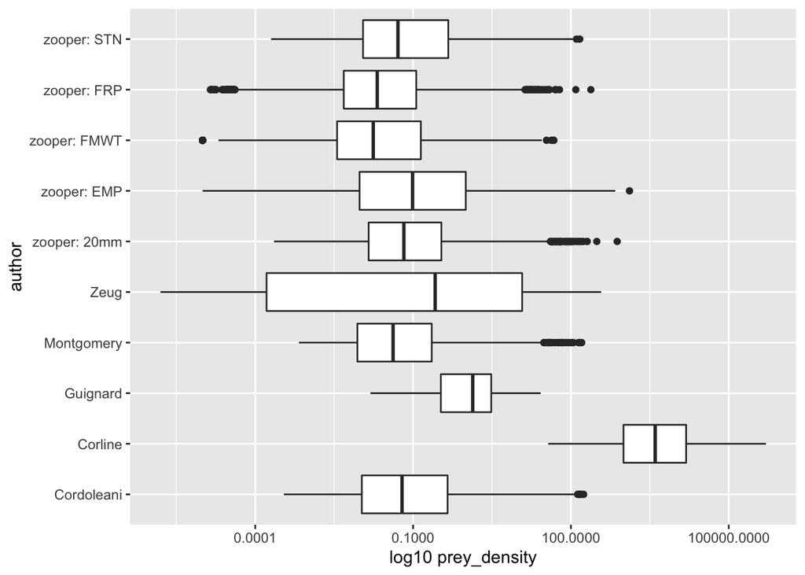

```r
ggplot() +
  geom_boxplot(data = all_prey, aes(x = author, y = prey_density)) +
  scale_y_continuous(trans='log10') +
  ylab('log10 prey_density') +
  coord_flip()
```

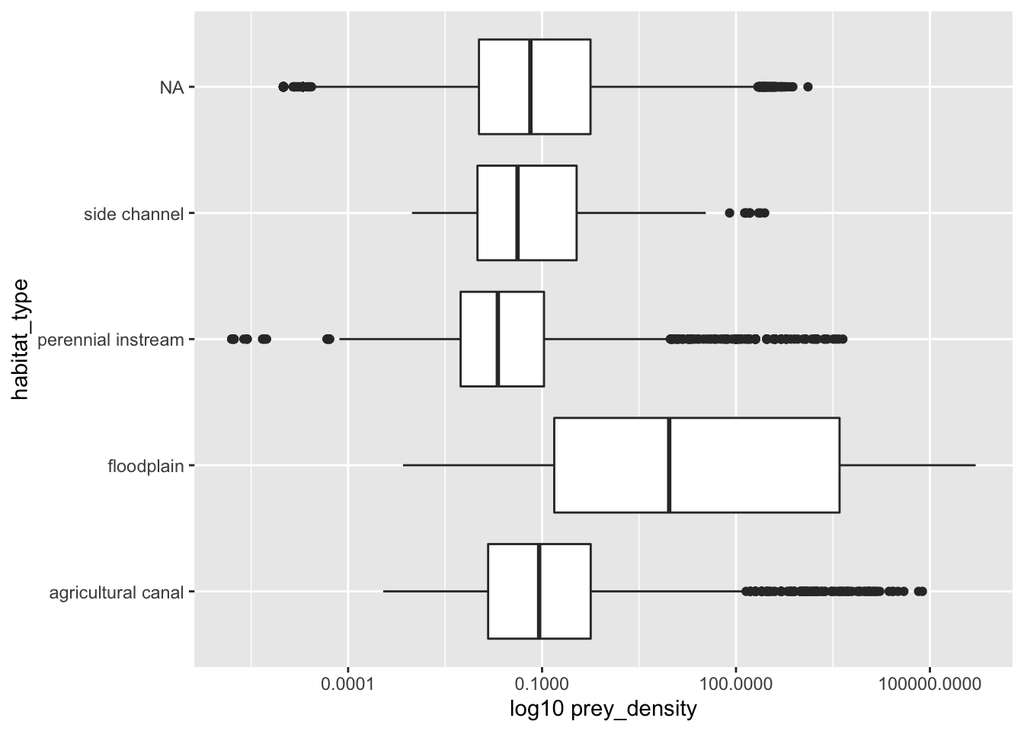

```r
ggplot() +
  geom_boxplot(data = all_prey, aes(x = habitat_type, y = prey_density)) +
  scale_y_continuous(trans='log10') +
  ylab('log10 prey_density') +
  coord_flip()
```

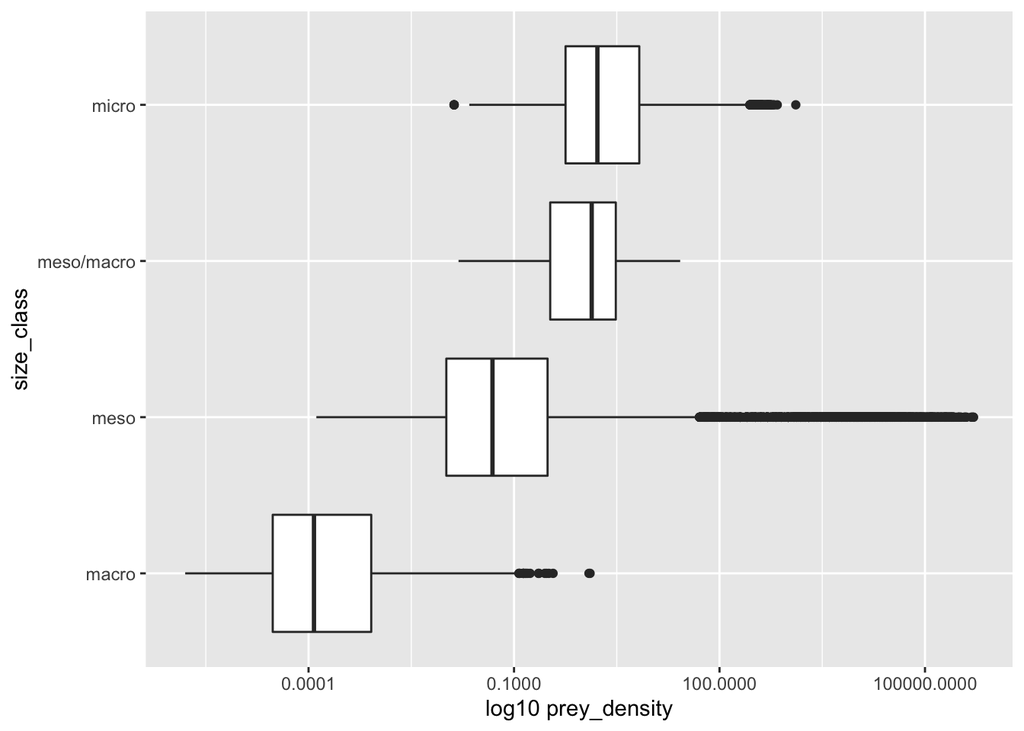

```r
ggplot() +
  geom_boxplot(data = all_prey, aes(x = size_class, y = prey_density)) +
  scale_y_continuous(trans='log10') +
  ylab('log10 prey_density') +
  coord_flip()
```

#### Raw Data Visualization

```r
all_prey %>%
  group_by(habitat_type) %>%
  select(prey_density) %>%
  summarise_if(is.numeric, .funs = c("mean", "min", "max", "var"), na.rm = TRUE) %>%
  kable(digits=1, format.args = list(big.mark = ","))
```

| habitat_type | mean | min | max | var |
| --- | --- | --- | --- | --- |
| agricultural canal | 157.8 | 0 | 76,500.0 | 4,509,912.3 |
| floodplain | 11,114.5 | 0 | 510,000.0 | 1,465,478,525.7 |
| perennial instream | 9.4 | 0 | 4,500.0 | 16,814.2 |
| side channel | 4.6 | 0 | 278.0 | 734.3 |
| NA | 0.7 | 0 | 1,298.8 | 63.0 |

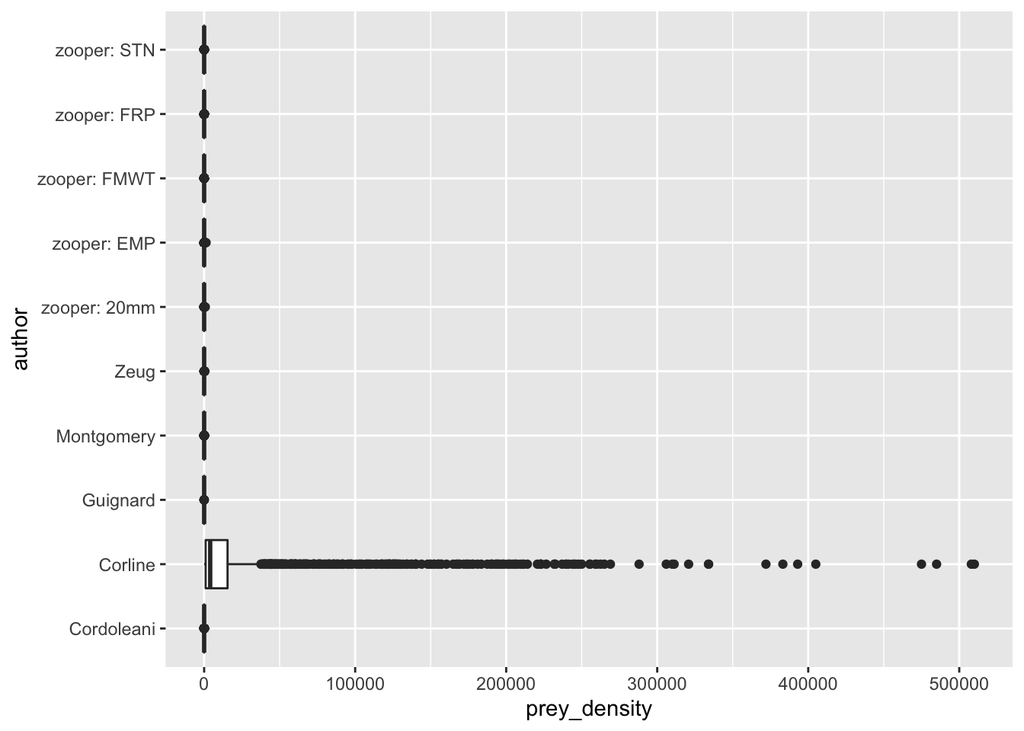

```r
ggplot() +
  geom_boxplot(data = all_prey, aes(x = author, y = prey_density)) +
  coord_flip()
```

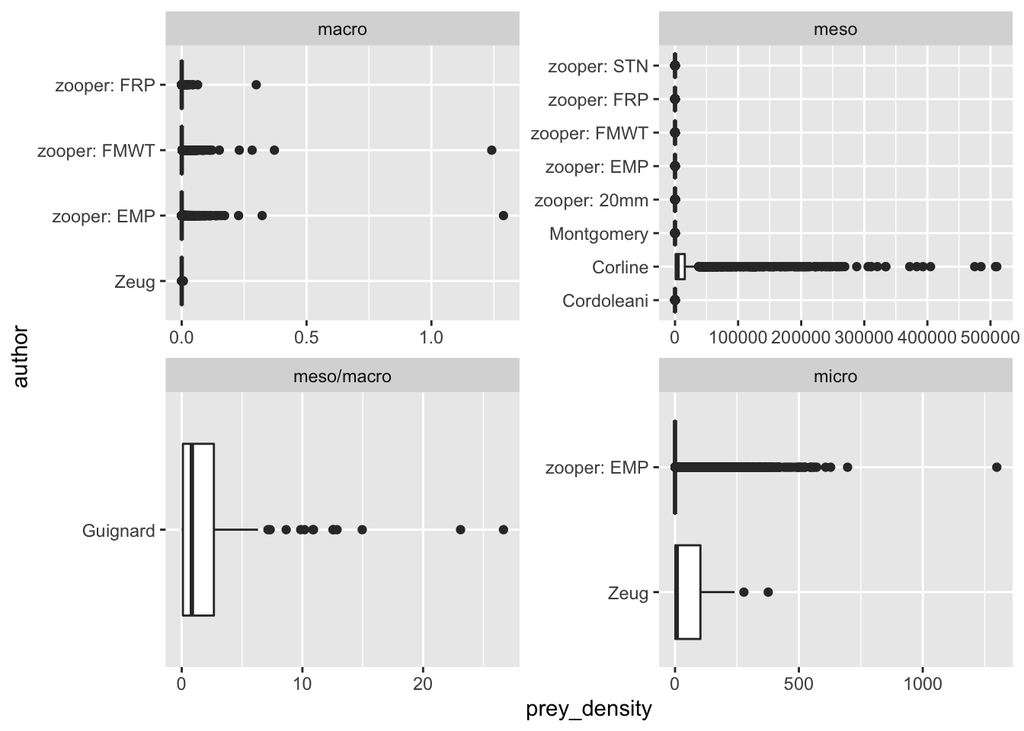

```r
ggplot() +
  geom_boxplot(data = all_prey, aes(x = author, y = prey_density)) +
  facet_wrap(~size_class, scale = "free") +
  coord_flip()
```

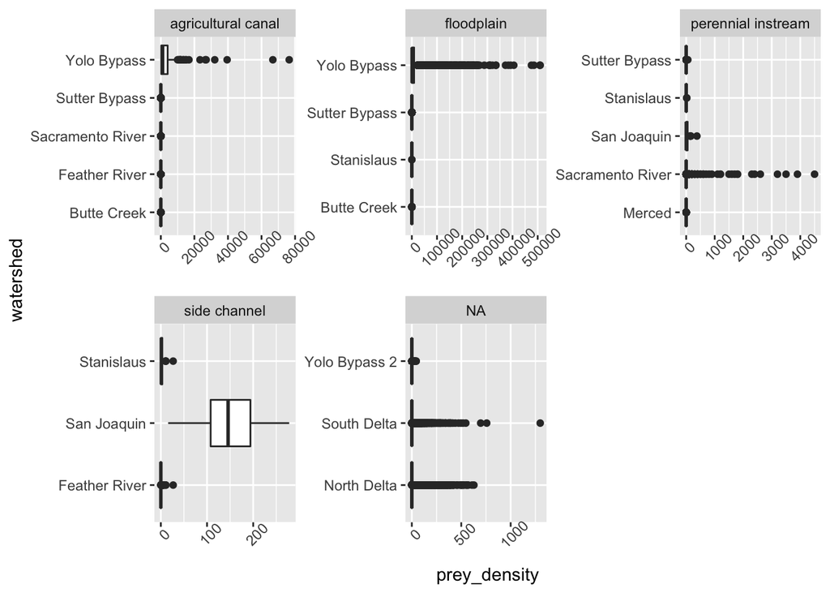

```r
ggplot() +
  geom_boxplot(data = all_prey, aes(x = watershed, y = prey_density)) +
  facet_wrap(~habitat_type, scale = "free") +
  theme(axis.text.x = element_text(angle = 45)) +
  coord_flip()
```

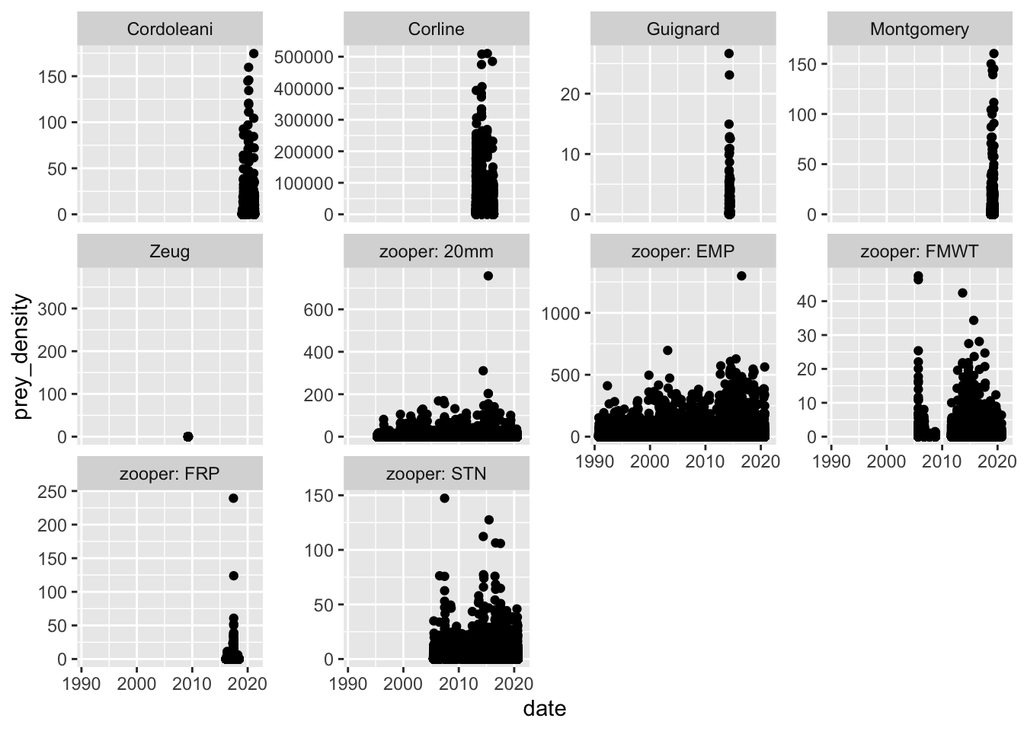

```r
ggplot() +
  geom_point(data = all_prey, aes(x = date, y = prey_density)) +
  facet_wrap(~author, scales= "free_y")
```

## Fish Data

```r
all_fish <- bind_rows(cordoleani_fish,
                      merced_steve_zeug_fish,
                      montgomery_fish
)

kable(head(all_fish, 10))
```

| fish_id | habitat_type | date | mass | author | fork_length | watershed | lat | lon | site |
| --- | --- | --- | --- | --- | --- | --- | --- | --- | --- |
| 4418 | perennial instream | 2019-03-19 | 2.619009 | Cordoleani | 56.78261 | Butte Creek | 39.3607 | -121.8936 | Butte Sink-BSC1 |
| 4197 | agricultural canal | 2020-03-10 | 1.360000 | Cordoleani | 56.78261 | Butte Creek | 39.3607 | -121.8936 | Butte Sink-BSC1 |
| 4181 | agricultural canal | 2020-02-10 | 1.490000 | Cordoleani | 56.78261 | Butte Creek | 39.3607 | -121.8936 | Butte Sink-BSC1 |
| 4418 | perennial instream | 2019-04-02 | 3.235880 | Cordoleani | 56.78261 | Butte Creek | 39.3607 | -121.8936 | Butte Sink-BSC1 |
| 3975 | perennial instream | 2019-02-20 | 1.069143 | Cordoleani | 56.78261 | Butte Creek | 39.3607 | -121.8936 | Butte Sink-BSC1 |
| 3914 | agricultural canal | 2020-03-10 | 1.330000 | Cordoleani | 56.78261 | Butte Creek | 39.3607 | -121.8936 | Butte Sink-BSC1 |
| 4479 | agricultural canal | 2020-03-10 | 1.600000 | Cordoleani | 56.78261 | Butte Creek | 39.3607 | -121.8936 | Butte Sink-BSC1 |
| 4197 | agricultural canal | 2020-03-16 | 1.370000 | Cordoleani | 56.78261 | Butte Creek | 39.3607 | -121.8936 | Butte Sink-BSC1 |
| 4418 | perennial instream | 2019-02-20 | 1.123693 | Cordoleani | 56.78261 | Butte Creek | 39.3607 | -121.8936 | Butte Sink-BSC1 |
| 4332 | perennial instream | 2019-04-02 | 3.663739 | Cordoleani | 56.78261 | Butte Creek | 39.3607 | -121.8936 | Butte Sink-BSC1 |

```r
# saveRDS(all_fish, '../preliminary data/aggregated_fish_data.rds')
```

### Explore Fish Data

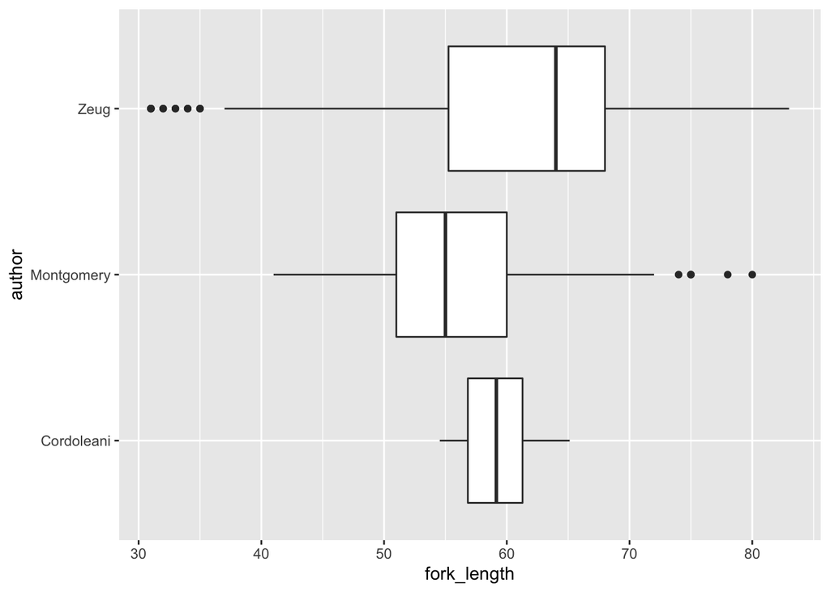

```r
ggplot() +
  geom_boxplot(data = all_fish, aes(x = author, y = fork_length)) +
  coord_flip()
```

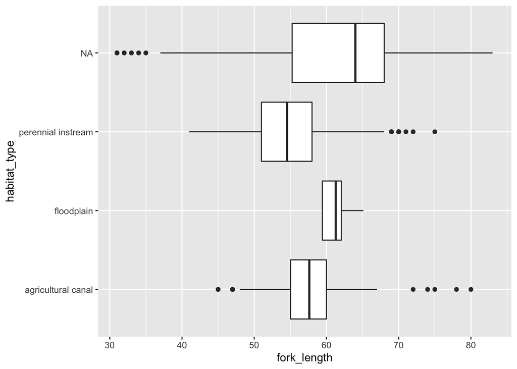

```r
ggplot() +
  geom_boxplot(data = all_fish, aes(x = habitat_type, y = fork_length)) +
  coord_flip()
```

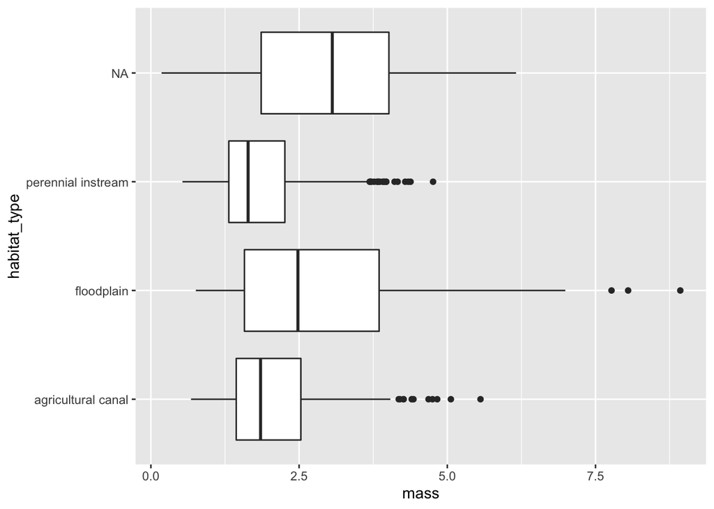

```r
ggplot() +
  geom_boxplot(data = all_fish, aes(x = habitat_type, y = mass)) +
  coord_flip()
```

## Environmental Data

```r
all_enviro <- bind_rows(cordoleani_enviro,
                        merced_steve_zeug_temp,
                        montgomery_temp,
                        stanislaus_temp_data,
                        zooper_temperature)

kable(head(all_enviro, 10))
```

| site | habitat_type | date | do_mg_l | temperature | author | watershed | lat | lon | flow_cfs |
| --- | --- | --- | --- | --- | --- | --- | --- | --- | --- |
| Butte Sink-BSA1 | agricultural canal | 2021-02-27 | 6.81 | 12.08 | Cordoleani | Butte Creek | 39.235 | -121.947 | NA |
| Butte Sink-BSA1 | agricultural canal | 2021-03-19 | 8.29 | 10.32 | Cordoleani | Butte Creek | 39.235 | -121.947 | NA |
| Butte Sink-BSA1 | agricultural canal | 2021-02-27 | 6.80 | 11.88 | Cordoleani | Butte Creek | 39.235 | -121.947 | NA |
| Butte Sink-BSA1 | agricultural canal | 2021-03-20 | 7.53 | 15.60 | Cordoleani | Butte Creek | 39.235 | -121.947 | NA |
| Butte Sink-BSA1 | agricultural canal | 2021-03-20 | 6.30 | 9.54 | Cordoleani | Butte Creek | 39.235 | -121.947 | NA |
| Butte Sink-BSA1 | agricultural canal | 2021-03-20 | 7.38 | 15.76 | Cordoleani | Butte Creek | 39.235 | -121.947 | NA |
| Butte Sink-BSA1 | agricultural canal | 2021-03-20 | 6.34 | 9.44 | Cordoleani | Butte Creek | 39.235 | -121.947 | NA |
| Butte Sink-BSA1 | agricultural canal | 2021-03-20 | 7.73 | 16.40 | Cordoleani | Butte Creek | 39.235 | -121.947 | NA |
| Butte Sink-BSA1 | agricultural canal | 2021-03-20 | 6.85 | 16.50 | Cordoleani | Butte Creek | 39.235 | -121.947 | NA |
| Butte Sink-BSA1 | agricultural canal | 2021-02-28 | 9.07 | 9.32 | Cordoleani | Butte Creek | 39.235 | -121.947 | NA |

```r
# saveRDS(all_enviro, '../preliminary data/aggregated_enviro_data.rds')
```

### Explore Environmental Data

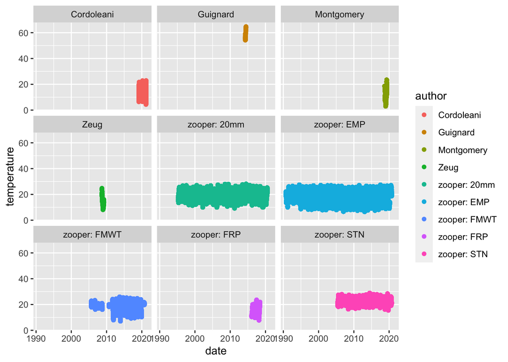

```r
ggplot() +
  geom_point(data = all_enviro, aes(x = date, y = temperature, color = author)) +
 facet_wrap(~author)
```

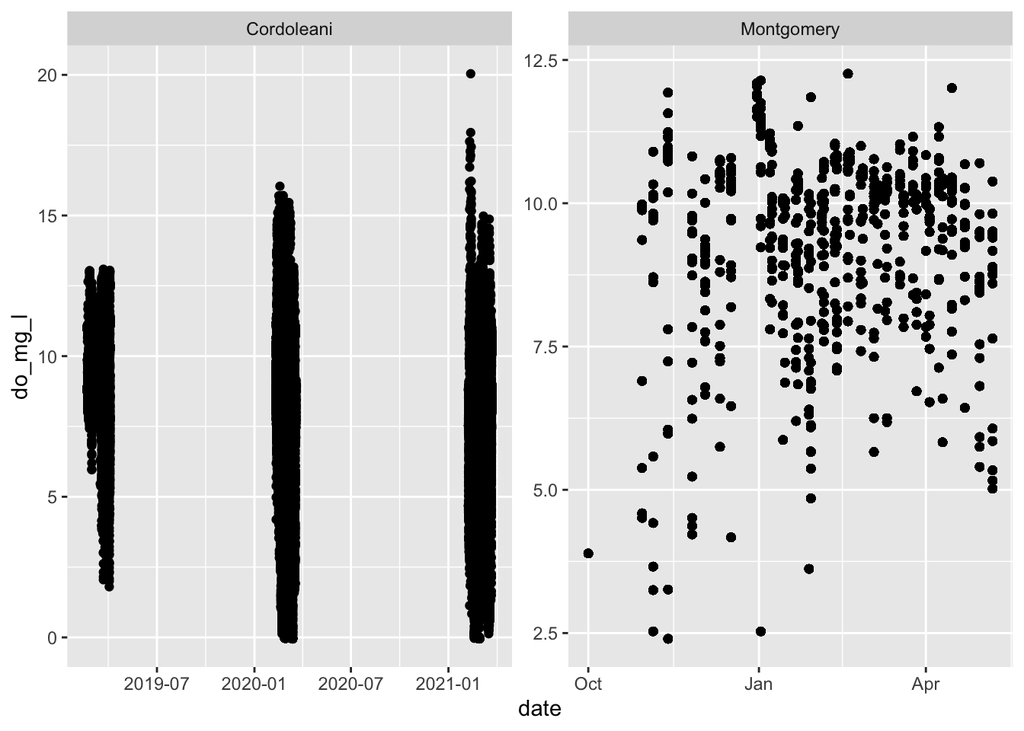

```r
#theme(legend.position="none")

do <- all_enviro %>% filter(author %in% c('Cordoleani', 'Montgomery'))
ggplot() +
  geom_point(data = do, aes(x = date, y = do_mg_l)) +
  facet_wrap(~author, scales = 'free')
```

[^1]: constructed nine 0.79-ha experimental units on Knaggs Ranch in the north end of the Yolo Bypass (Fig. 1). Fields were inundated on Febuary 5th 2013 with water from Knights Landing Ridge Cut, a channel that drains the Colusa Basin and supplies agricultural water to the Yolo Bypass, and were drained on March 27th 2013. Flow to the fields was variable and ranged from 0.3-0.5 meters. Flow rates into the fields ranged from 0.0 to 0.06 cubic meters per second. Each field was stocked with *4500 juvenile Chinook Salmon from the Feather River Hatchery (Oroville, CA), which initially measured approximately 53.6 ± 0.15 mm FL.
[^2]: Sacramento River Zooplankton: Zooplankton samples were collected concurrently during the study period at Sherwood Harbor on the Sacramento River by the California Department of Water Resources using methods from Sommer et al. (2001a, b, 2004). Samples were collected with a 153 lm mesh 0.5 m diameter Clark-Bumpus net equipped with a General Oceanics Flowmeter (Miami, FL, USA) and preserved in 5% formalin. Flow meter distance and net dimensions were used to calculate zooplankton per cubic meter.
[^3]: Inlet Canal: The source water inlet canal was sampled prior to inundation and then during weeks three, four, five, and six. To assess invertebrate diversity and abundance on different habitat types and the inlet canal, a 153 lm zooplankton net attached to5 m of rope was thrown the full 5-m distance and retrieved four times for a total volume of 1.92 cubic meters sampled per sample.